# Integrity, transparency, and accountability analysis

Viktoriia Poltoratskaia

2025-12-11

This analysis examines transparency and accountability challenges in public procurement systems using procurement data. The tool provides a framework for assessing the extent to which regulatory requirements are reflected in actual implementation, focusing on transparency and accountability as key determinants of procurement integrity and corruption risk. Beyond evaluating data availability and accessibility, the analysis proposes tests to identify potential collusive relationships between buyers and suppliers and assesses how transparency affects competition and price overruns.

### Is there a legal mandate to ensure information accessibility?

Requires manual filling

#### Electronic Procurement and Online Access to Procurement Data

| Indicator | Source |
| --- | --- |
| Is there a legal framework requiring or enabling the use of e-procurement systems (electronic means) as the standard means of communication and information exchange in procurement procedures? | SIGMA Brief No. 17 (E-Procurement); MAPS assessment; National legislation |

#### Legal Requirement for Publishing Tender Information

| Indicator | Source |
| --- | --- |
| Does the procurement law mandate the publication of tender documents, bidding documents, awarded contracts and subcontracting in a central and publicly accessible platform (including framework agreeme… | EuroPAM Public Procurement Indicators — Qual-16 to Qual-22; MAPS assessment; National legislation |
| Are there any procedures that are excluded from the requirement of publication? | EuroPAM Public Procurement Indicators — Qual-16 to Qual-22; MAPS assessment; National legislation |

#### Central Oversight

| Indicator | Source |
| --- | --- |
| Does the law establish a dedicated central procurement authority or regulatory body responsible for overseeing transparency and compliance with procurement regulations? | SIGMA Brief No. 26 (Organizing Central Public Procurement Functions); EuroPAM indicator Qual-57; MAPS assessment; National legislation |

### Is data open, machine readable and not missing any crucial fields?

#### Platform information

Requires manual filling

| Field | Value |
| --- | --- |
| Platform URL |  |
| Year of introduction |  |
| Type of access | Free / paid / limited |

#### Data fields

Requires manual filling

| Field | Is available? | Type of data |
| --- | --- | --- |
| Procurement plans | Yes/No | Scanned PDFs / xml / html / no information |
| Call for tenders | Yes/No | Scanned PDFs / xml / html / no information |
| Modification or cancellation | Yes/No | Scanned PDFs / xml / html / no information |
| Announcement of awards | Yes/No | Scanned PDFs / xml / html / no information |
| Details on contract signature | Yes/No | Scanned PDFs / xml / html / no information |
| Implementation information | Yes/No | Scanned PDFs / xml / html / no information |
| Framework agreement | Yes/No | Scanned PDFs / xml / html / no information |
| Direct awards | Yes/No | Scanned PDFs / xml / html / no information |
| Subcontractors | Yes/No | Scanned PDFs / xml / html / no information |

**Source:** National platform website

## Country-specific results

### Bulgaria (BG)

#### Basic data summary for BG

**Contracts per year:**

| Tender year | Number of contracts |
| --- | --- |
| 2007 | 7715 |
| 2008 | 11552 |
| 2009 | 8595 |
| 2010 | 10424 |
| 2011 | 14393 |
| 2012 | 18833 |
| 2013 | 20472 |
| 2014 | 20723 |
| 2015 | 20698 |
| 2016 | 14857 |
| 2017 | 9480 |
| 2018 | 10549 |
| 2019 | 9500 |
| 2020 | 614 |
| NA | 6912 |

**Number of unique buyers (buyer_masterid):** 30,160

**Number of unique bidders (bidder_masterid):** 106,703

**Number of unique tenders per year:**

| Tender year | Number of unique tenders |
| --- | --- |
| 2007 | 4604 |
| 2008 | 7037 |
| 2009 | 3704 |
| 2010 | 3174 |
| 2011 | 4038 |
| 2012 | 7175 |
| 2013 | 9409 |
| 2014 | 9384 |
| 2015 | 8869 |
| 2016 | 7666 |
| 2017 | 6827 |
| 2018 | 7470 |
| 2019 | 6097 |
| 2020 | 365 |
| NA | 6912 |

**Variables present (excluding indicator variables):**

- tender_id
- lot_number
- bid_number
- bid_iswinning
- tender_country
- tender_awarddecisiondate
- tender_contractsignaturedate
- tender_biddeadline
- tender_proceduretype
- tender_nationalproceduretype
- tender_supplytype
- tender_publications_firstcallfortenderdate
- notice_url
- source
- tender_publications_firstdcontractawarddate
- tender_publications_lastcontractawardurl
- buyer_masterid
- buyer_id
- buyer_city
- buyer_postcode
- buyer_country
- buyer_nuts
- buyer_name
- buyer_buyertype
- buyer_mainactivities
- tender_addressofimplementation_country
- tender_addressofimplementation_nuts
- bidder_masterid
- bidder_id
- bidder_country
- bidder_nuts
- bidder_name
- bid_price
- bid_priceusd
- bid_pricecurrency
- lot_productcode
- lot_localproductcode_type
- lot_localproductcode
- submp
- decp
- is_capital
- lot_title
- lot_estimatedpriceusd
- lot_estimatedprice
- lot_estimatedpricecurrency
- tender_year

#### Are there observable patterns of underreporting information in the data?

The first step is to assess data completeness by examining missing values across all variables or a defined subset. Given the limited number of variables in the ProAct dataset, a full review can be efficiently conducted to identify any variables with significant underreporting. Each variable contributed to one of the ProAct indicators.

#### Overall Missing Values by Variable – BG

This figure summarises the share of missing values for each key variable in the dataset. For every non-indicator column (all variables that do not start with ‘ind_’), the pipeline computes the mean of an NA indicator across all observations, i.e. the proportion of records where that field is missing. Variables are displayed with human-readable labels (e.g. buyer and bidder IDs, names, locations, prices). Use this plot to identify which core fields are most affected by missingness and may compromise analysis – especially high-missingness identifiers, dates, and price variables.

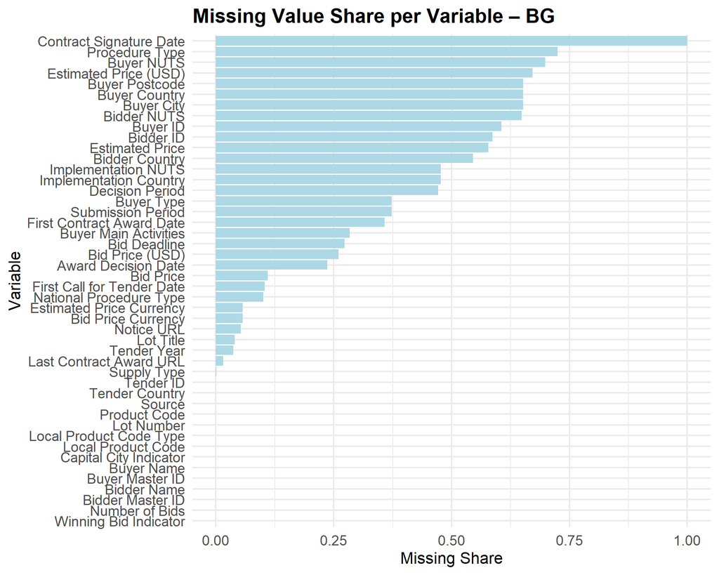

#### Missingness by Buyer Type – BG

This heatmap shows how missingness varies across buyer types and variables. Buyers are categorised into ‘National’, ‘Regional’, ‘Utilities’, ‘EU agency’, and ‘Other Public Bodies’ based on the ‘buyer_buyertype’ field. For each buyer group, the pipeline computes the share of missing values for all non-indicator variables and reshapes them into a long format. Darker cells indicate a higher proportion of missing values for a given variable within a buyer group. Pay particular attention to patterns where specific buyer types systematically lack key identifiers (e.g. buyer IDs, names, addresses) or financial fields, as these gaps may signal structural reporting issues.

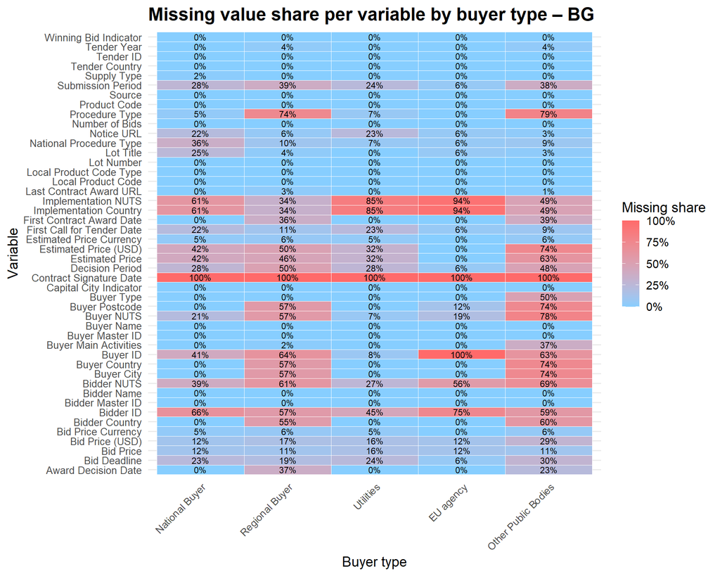

#### Missingness Among Top Buyers – BG

This bar chart highlights the top 10 buyers with the highest overall share of missing data. The underlying calculation groups the data by ‘buyer_name’ and ‘buyer_buyertype’, keeps only buyers with at least 100 records, and then computes the average share of missing values across all non-indicator variables. Labels show truncated buyer names with buyer type on the next line. Use this figure to spot specific organisations that drive data quality problems: buyers with very high missingness may require targeted engagement or manual cleaning before deeper analysis.

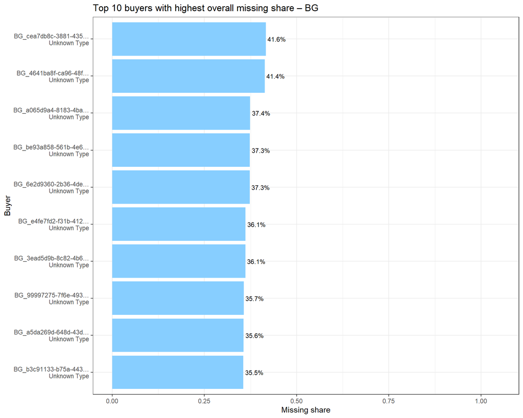

#### Missingness by Procedure Type – BG

This heatmap displays the share of missing values for each variable, broken down by procurement procedure type. The pipeline recodes ‘tender_proceduretype’ into readable procedural categories (e.g. Open, Restricted, Negotiated with/without publication, Outright award, Competitive dialogue), then computes missingness shares for all non-indicator variables by procedure group and reshapes to long format. Each cell gives the proportion of missing values for a given variable within a procedure type. Look for procedure types where key information (such as buyer and bidder identifiers, contract values, or dates) is systematically missing – this may indicate opacity in less competitive or exceptional procedures.

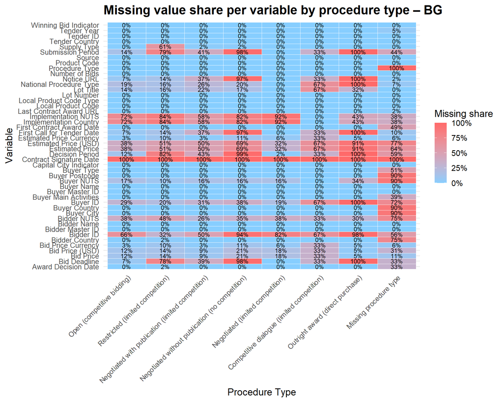

#### Trends in Missing Shares Over Time – BG

This line plot tracks how missingness evolves over time for the 10 variables with the highest average missing share. For each ‘tender_year’, the pipeline computes missingness shares for all non-indicator variables, identifies the top 10 variables with the largest average missingness, and then plots their yearly trajectories. Lines show the proportion of missing values by year for each selected variable. Use this figure to detect whether data quality is improving, deteriorating, or abruptly changing around certain years, and to identify critical breaks that might be linked to system changes, regulatory reforms, or data migration issues.

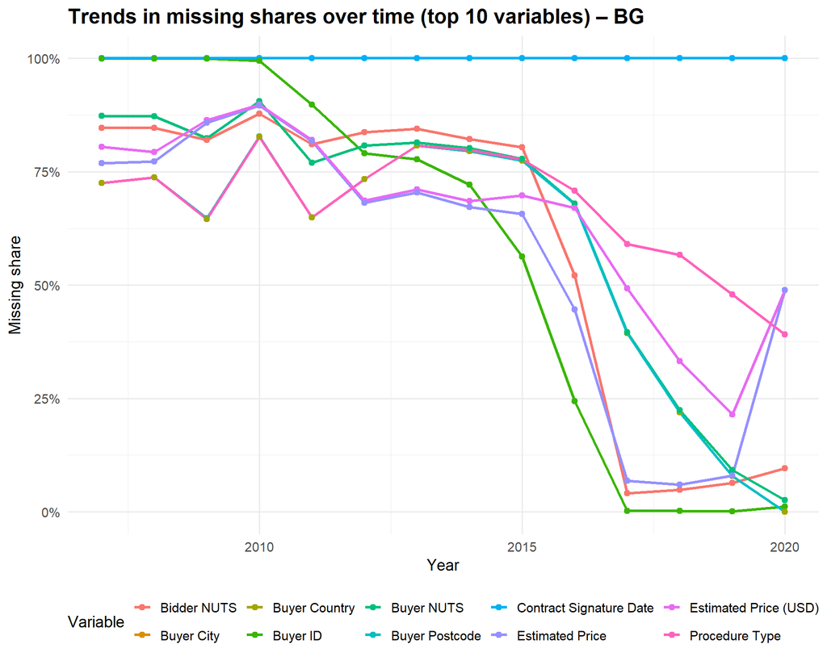

#### Missingness by Region (NUTS3) – BG

This choropleth map shows the overall share of missing values by NUTS3 region, where such information is available. The pipeline first cleans ‘buyer_nuts’ codes into valid NUTS3 identifiers, then computes the average share of missing values across all non-indicator variables for each region. These regional missingness rates are then joined to Eurostat NUTS3 geometries for the selected country (year 2021) and plotted. Regions shaded in darker colours have a higher share of missing information in buyer-level or contract-level fields. Pay attention to regions where missingness is systematically high, as this may reflect regional reporting capacity issues or gaps in how certain subnational entities interact with the procurement system.

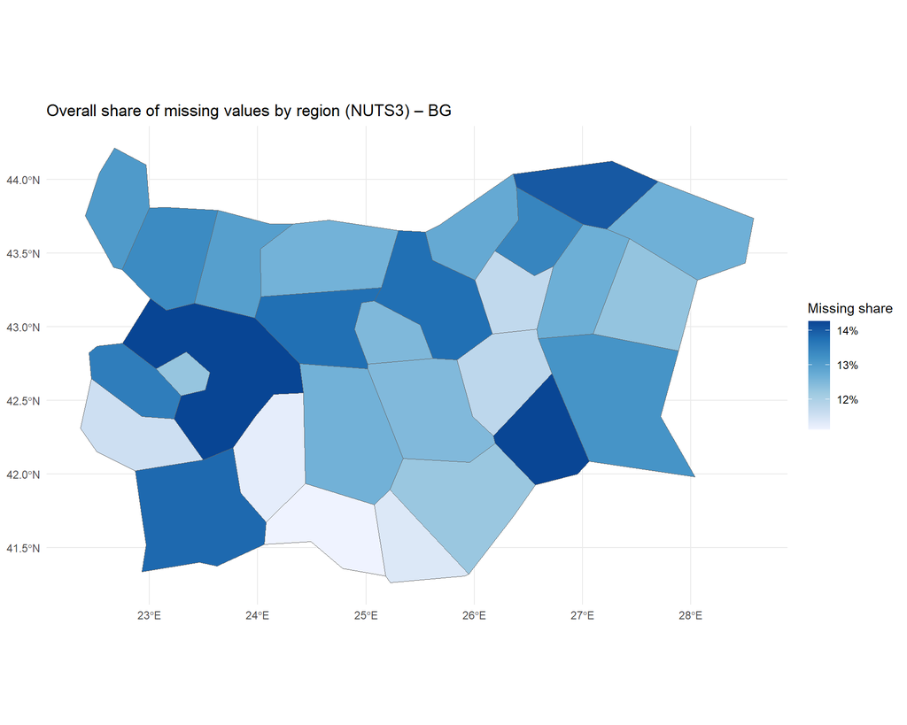

#### Can this data be matched to other registers in the country to ensure higher quality monitoring?

The ability to match public procurement data with other registers significantly enhances the analytical power of research and strengthens auditing capabilities. Most importantly, access to company register or beneficial ownership data provides valuable insights into the supplier side—such as how long the firm has been operating, its profitability, the ratio of contract value to revenue, and how closely the procurement sector aligns with the company’s main area of activity.

In addition, linking buyers to relevant information about the government agency can greatly improve analysis on the buyer side, for instance by incorporating data on politically exposed persons or asset declarations. Finally, geospatial information can offer further insights into the location of the company or the procuring agency, enriching both analytical and oversight capacities.

#### Other types of national data available for matching

Requires manual filling

| Data type | Availability (access + format) | ID type | Comments |
| --- | --- | --- | --- |
| Company register | Open / restricted / paid + file format | Tax ID / other national ID / BvD ID | Can be used as external validation source |
| Beneficial ownership data | Open / restricted / paid + file format | Tax ID / other national ID / BvD ID | Can share data per requested list of companies |
| Asset and interest declarations | Open / restricted / paid + file format | Name of politician / Personal Tax ID / other | Often requires manual collection or scraping |

#### Case-specific analysis – matching rate between data sources

Can be filled when respective data is available

| Dataset A | Dataset B | Identifier | Matching rate |
| --- | --- | --- | --- |
| Procurement | Company register | Supplier ID + year | 0–100% |
| Company register | PEP data | Name | 0–100% |

**Source:** Contract-level data; company register records; other micro data

#### Interoperability potential at organization level

| Organization type | ID type | Missing share |
| --- | --- | --- |
| Supplier | Source ID | 59% |
| Supplier | Generated ID | 0% |
| Supplier | Name | 0% |
| Supplier | Address (postcode) | 65% |
| Buyer | Source ID | 61% |
| Buyer | Generated ID | 0% |
| Buyer | Name | 0% |
| Buyer | Address (postcode) | 65% |

#### Do companies winning contracts have risky profiles?

This analysis seeks to identify potentially suspicious patterns in company behavior, including movements between markets or registration in tax haven jurisdictions. With access to company and beneficial ownership register data, additional and more sophisticated indicators could be developed.

#### Network of Unusual Supplier Market Entries – BG

This network visualisation maps atypical movements of suppliers across CPV product clusters. Each node represents a 3-digit CPV cluster, i.e. a broad product or service market derived from ‘lot_productcode’. For every bidder, a ‘home’ CPV cluster is defined as the cluster where the bidder wins the most awards. Entries into other clusters are treated as ‘target’ markets. A bidder–cluster combination is flagged as atypical if the bidder has enough overall history, but that cluster accounts for less than 5% of their awards and at most three wins there. For each bidder–cluster pair, the pipeline computes a Laplace-smoothed probability of observing that bidder in that cluster, p(i|c) = (n_ic + 1) / (n_c + n_suppliers_c), where n_ic is the number of contracts for bidder i in cluster c, n_c is the total number of contracts in c, and n_suppliers_c is the number of distinct suppliers in c. The surprise score is then defined as -log(p(i|c)) and standardised to a z-score; higher values indicate that the bidder is unusually rare in that cluster given its overall structure. These atypical entries are aggregated at the level of home CPV cluster (source) and target CPV cluster (destination). Directed edges are drawn only for pairs of clusters where at least four distinct bidders make such atypical entries. Edge width reflects the number of bidders involved (n_bidders), and edge colour encodes the average standardised surprise score: thicker and redder edges mark flows where many suppliers enter a target market in a way that is collectively more unusual than average. Node positions are based on a force-directed layout (Fruchterman–Reingold) and help visually cluster markets that are strongly connected by unusual flows. When interpreting the figure, focus on CPV clusters with multiple thick, high-surprise edges—either as sources or as targets—as these markets may concentrate non-standard or risky supplier behaviour that merits further qualitative investigation.

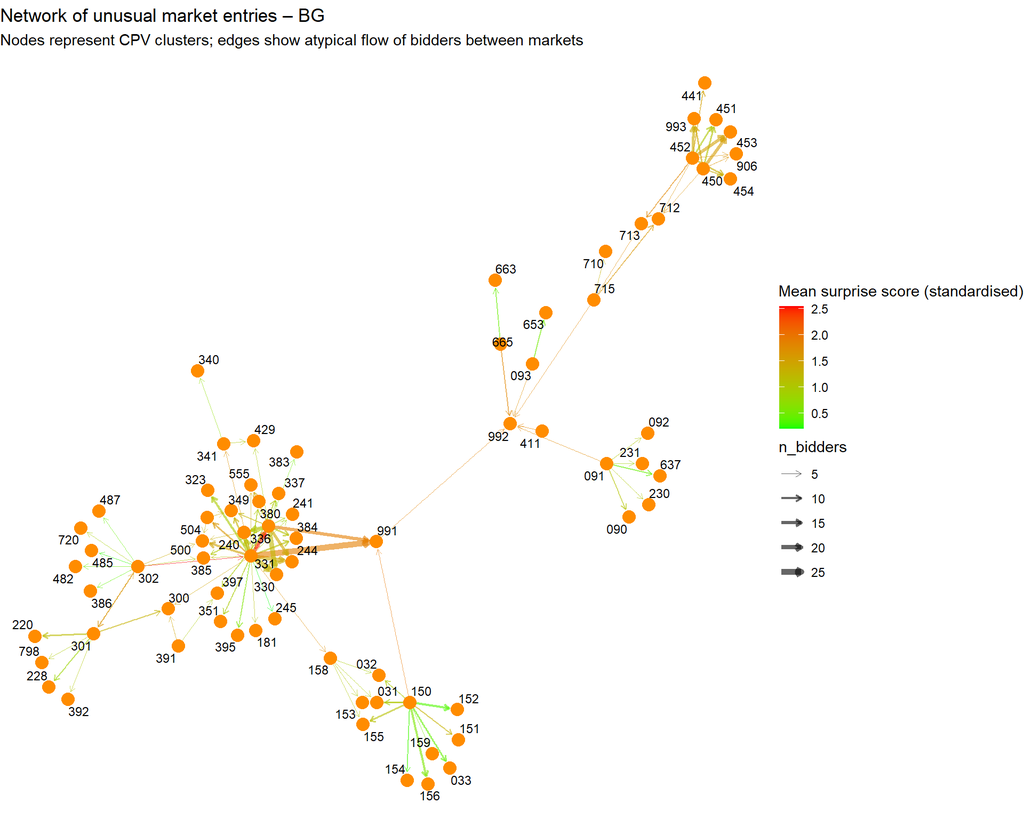

#### Suppliers with Unusually Diversified Market Entries – BG

Each bar represents a supplier flagged as behaving unusually across CPV clusters. For every bidder, the pipeline looks at all atypical CPV entries (those with high surprise z-scores) and records: the maximum surprise z-score attained across these entries, and the number of distinct target markets entered atypically. Bar height shows the maximum surprise z-score, while bar colour (if used) or additional labelling can indicate how many distinct markets each supplier enters in an unusual way. Use this figure to identify suppliers whose market expansion patterns are particularly non-standard and may warrant closer review.

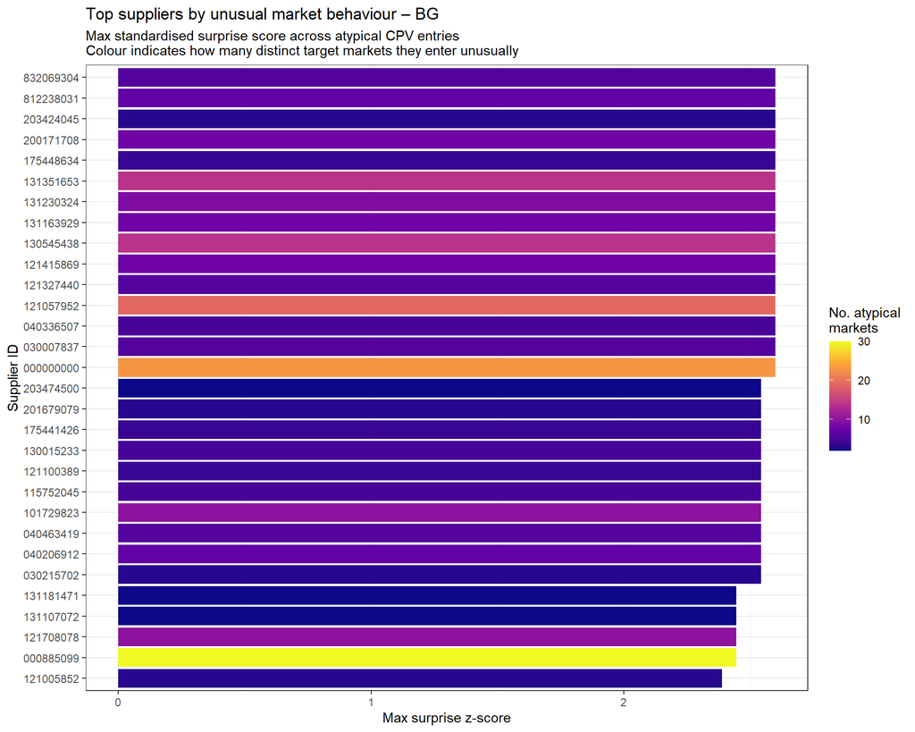

#### Markets Attracting Unusual Supplier Entries – BG

Each point represents a 3-digit CPV cluster (a broad product or service market). For each target cluster, the pipeline aggregates all atypical entries into that market and computes: (i) the number of distinct suppliers entering atypically (x-axis), (ii) the mean standardised surprise score among those entries (y-axis), and (iii) the number of atypical awards (bubble size). The resulting scatter/bubble plot highlights markets where many suppliers behave unusually (high x), where entries are particularly surprising on average (high y), or both. Clusters in the upper-right with large bubbles are markets that attract many highly atypical entries and may be especially relevant for risk-based follow-up.

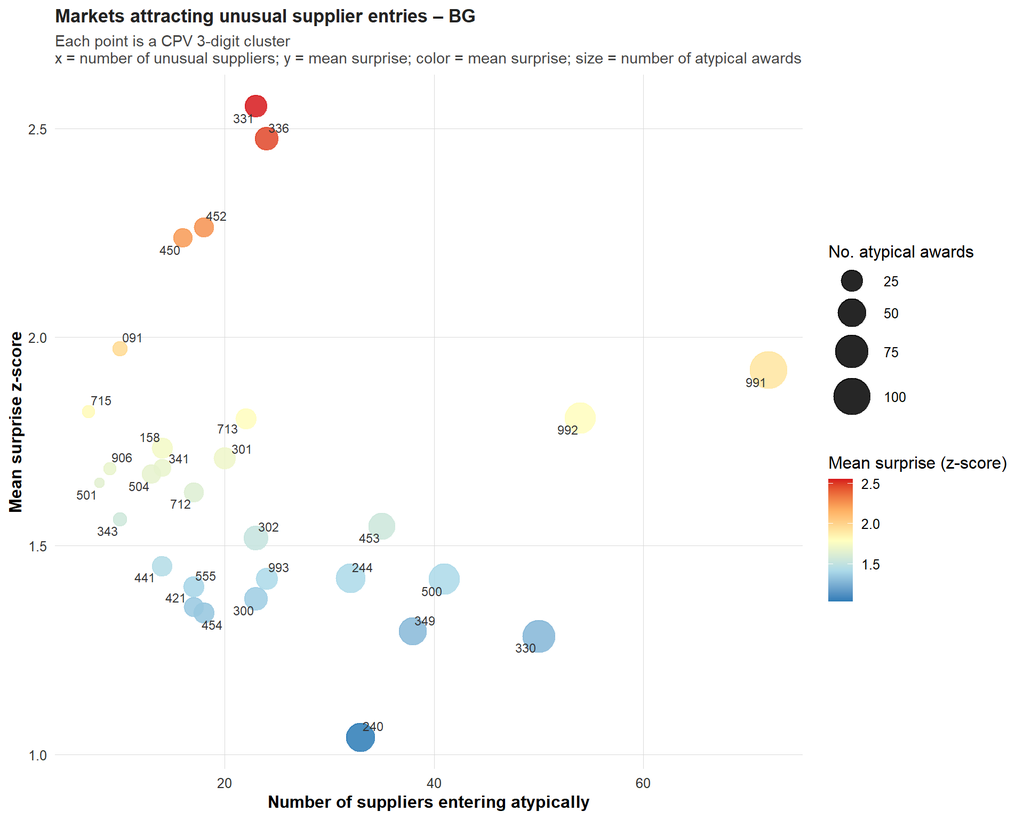

#### Are there suspicious connections between buyers and suppliers?

This analysis examines the potential existence of suspicious connections between buyers and suppliers. It can greatly benefit from access to additional registers—such as politically exposed persons (PEP) lists, interest or asset declaration databases, and beneficial ownership (BO) registers—as these can reveal direct links between suppliers and buyers.

#### Top Buyers by Supplier Concentration Over Time – BG

This faceted bar chart shows, for each year, the buyers with the highest concentration of spending on a single supplier. The pipeline groups contracts by ‘tender_year’, ‘buyer_masterid’, and ‘bidder_masterid’, computes total spend per buyer–supplier pair, and then derives, for each buyer-year, the share of spending allocated to each supplier (buyer_concentration). For buyers with at least three suppliers, the maximum of this share is used as the concentration indicator, and the top 30 buyer–year combinations per year are retained for plotting. Bars represent the maximum concentration for each buyer in a given year, labels show the number of contracts, and buyers that appear in the top list in more than one year are highlighted in red. High and persistent concentration (especially repeated red buyers across years) may signal stable and potentially problematic dependencies on single suppliers that merit closer investigation.

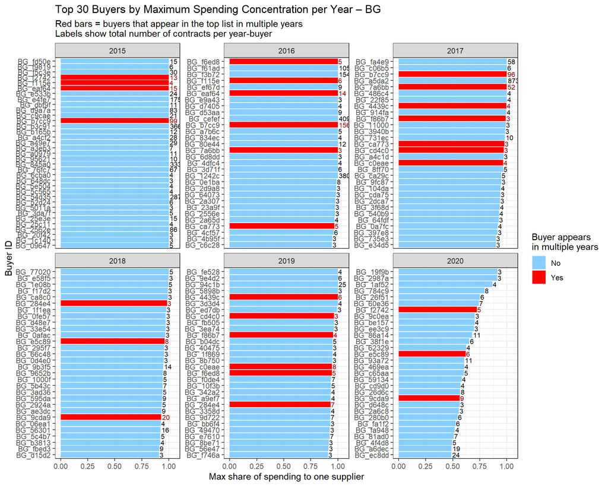

#### Is there an observable effect of transparency and integrity issues on prices and competition?

While this analysis does not establish any causal relationships, it can be used to explore correlations between transparency-related measures, prices, and competitiveness.

#### Predicted Single-Bidding by Missing Share – BG

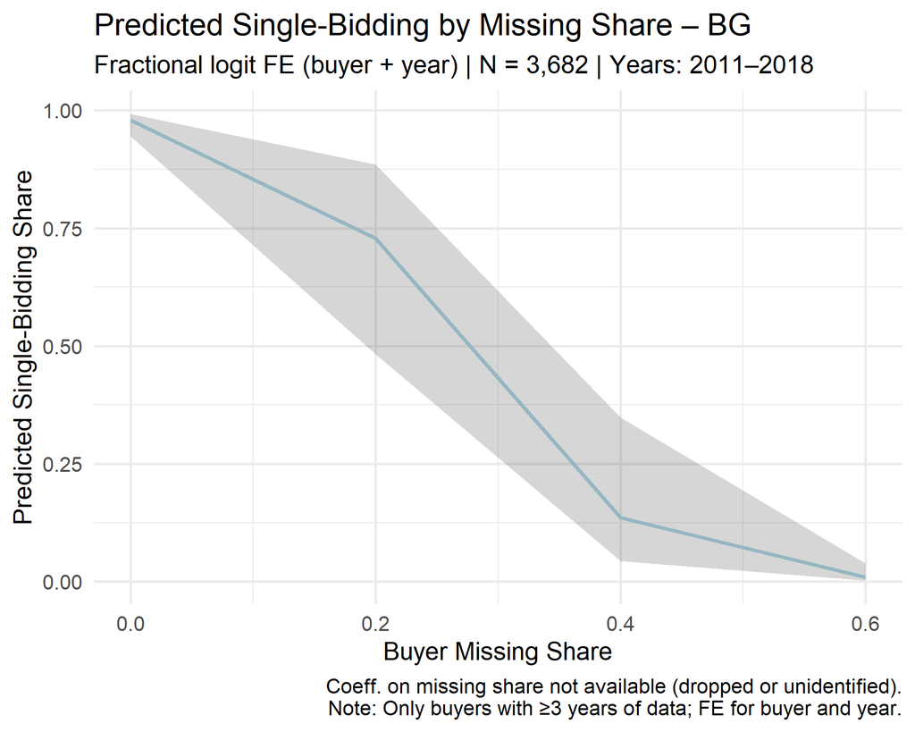

#### Predicted Relative Price by Missing Share – BG

This figure shows how relative prices correlate with overall missingness after controlling for key factors. For contracts with valid price information (bid price and estimated lot value), the pipeline computes ‘relative_price’ as bid_price / lot_estimatedprice and trims extreme or non-positive values. It then constructs ‘total_missing_share’ as the average of NA indicators across a predefined set of core variables, and estimates a linear fixed-effects model of relative_price on total_missing_share, controlling for procedure type, buyer type, and year (with year fixed effects and clustering by buyer). The line displays predicted relative prices as missingness increases, with a shaded 95% confidence interval. An upward relationship suggests that higher missingness – a proxy for weaker transparency and data quality – may be associated with higher prices relative to estimates; a flat line would indicate no clear price effect.

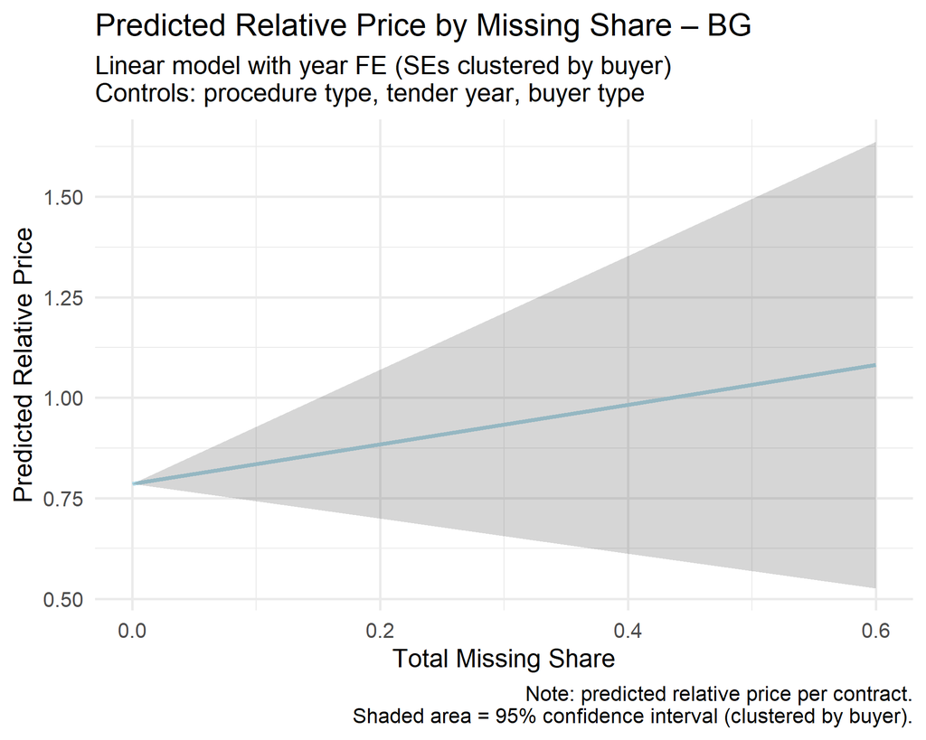

### Uruguat (UY)

#### Basic data summary for UY

**Contracts per year:**

| Tender year | Number of contracts |
| --- | --- |
| 2014 | 88 |
| 2015 | 57262 |
| 2016 | 71525 |
| 2017 | 85379 |
| 2018 | 46791 |

**Number of unique buyers (buyer_masterid):** 268

**Number of unique bidders (bidder_masterid):** 11,822

**Number of unique tenders per year:**

| Tender year | Number of unique tenders |
| --- | --- |
| 2014 | 45 |
| 2015 | 47122 |
| 2016 | 58670 |
| 2017 | 65622 |
| 2018 | 37364 |

**Variables present (excluding indicator variables):**

- tender_id
- lot_number
- bid_number
- tender_country
- tender_awarddecisiondate
- tender_biddeadline
- tender_proceduretype
- tender_nationalproceduretype
- tender_supplytype
- tender_publications_firstcallfortenderdate
- source
- buyer_masterid
- buyer_id
- buyer_name
- buyer_buyertype
- bidder_masterid
- bidder_id
- bidder_country
- bidder_name
- bid_price
- bid_priceusd
- bid_pricecurrency
- lot_productcode
- lot_localproductcode_type
- lot_localproductcode
- submp
- decp
- is_capital
- lot_title
- tender_year

#### Are there observable patterns of underreporting information in the data?

The first step is to assess data completeness by examining missing values across all variables or a defined subset. Given the limited number of variables in the ProAct dataset, a full review can be efficiently conducted to identify any variables with significant underreporting. Each variable contributed to one of the ProAct indicators.

#### Overall Missing Values by Variable – UY

This figure summarises the share of missing values for each key variable in the dataset. For every non-indicator column (all variables that do not start with ‘ind_’), the pipeline computes the mean of an NA indicator across all observations, i.e. the proportion of records where that field is missing. Variables are displayed with human-readable labels (e.g. buyer and bidder IDs, names, locations, prices). Use this plot to identify which core fields are most affected by missingness and may compromise analysis – especially high-missingness identifiers, dates, and price variables.

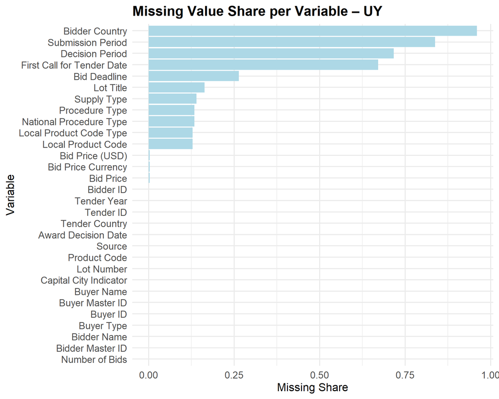

#### Missingness by Buyer Type – UY

This heatmap shows how missingness varies across buyer types and variables. Buyers are categorised into ‘National’, ‘Regional’, ‘Utilities’, ‘EU agency’, and ‘Other Public Bodies’ based on the ‘buyer_buyertype’ field. For each buyer group, the pipeline computes the share of missing values for all non-indicator variables and reshapes them into a long format. Darker cells indicate a higher proportion of missing values for a given variable within a buyer group. Pay particular attention to patterns where specific buyer types systematically lack key identifiers (e.g. buyer IDs, names, addresses) or financial fields, as these gaps may signal structural reporting issues.

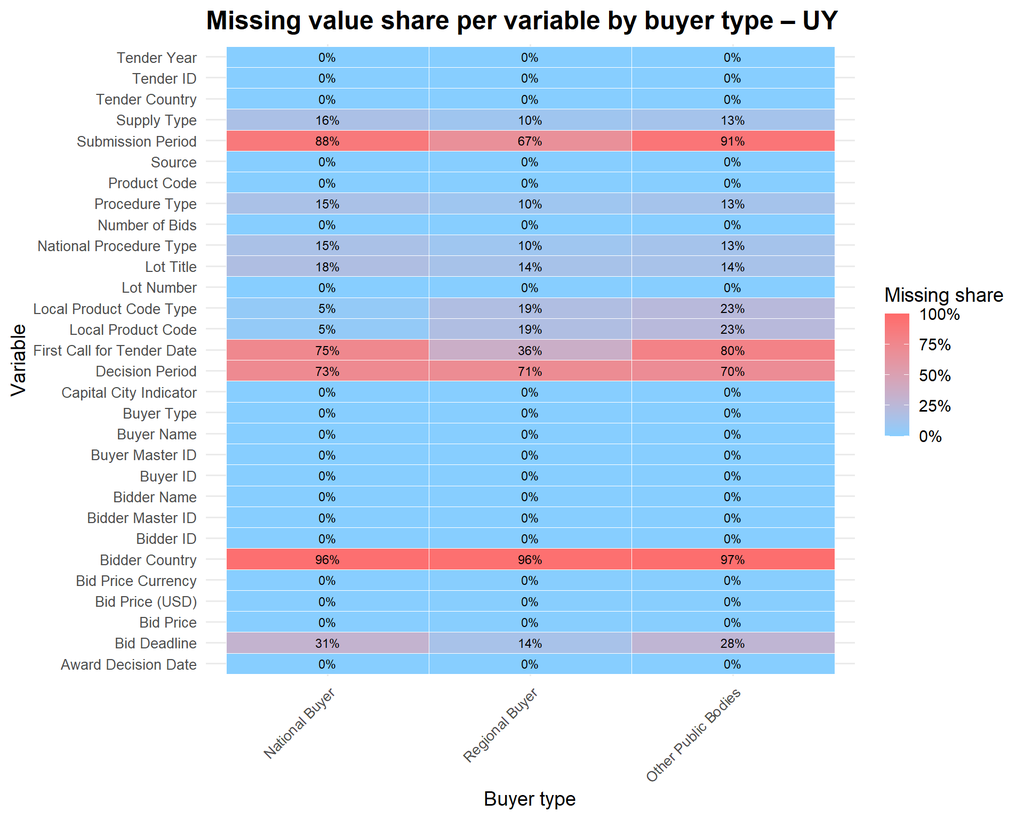

#### Missingness Among Top Buyers – UY

This bar chart highlights the top 10 buyers with the highest overall share of missing data. The underlying calculation groups the data by ‘buyer_name’ and ‘buyer_buyertype’, keeps only buyers with at least 100 records, and then computes the average share of missing values across all non-indicator variables. Labels show truncated buyer names with buyer type on the next line. Use this figure to spot specific organisations that drive data quality problems: buyers with very high missingness may require targeted engagement or manual cleaning before deeper analysis.

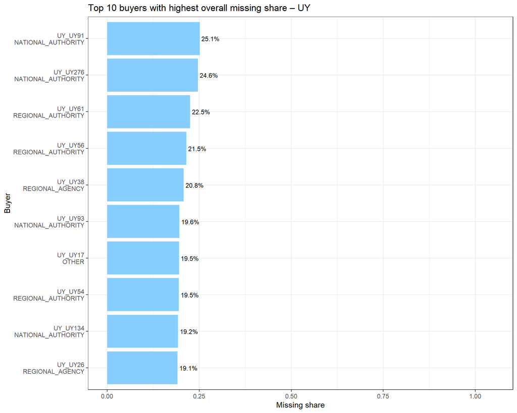

#### Missingness by Procedure Type – UY

This heatmap displays the share of missing values for each variable, broken down by procurement procedure type. The pipeline recodes ‘tender_proceduretype’ into readable procedural categories (e.g. Open, Restricted, Negotiated with/without publication, Outright award, Competitive dialogue), then computes missingness shares for all non-indicator variables by procedure group and reshapes to long format. Each cell gives the proportion of missing values for a given variable within a procedure type. Look for procedure types where key information (such as buyer and bidder identifiers, contract values, or dates) is systematically missing – this may indicate opacity in less competitive or exceptional procedures.

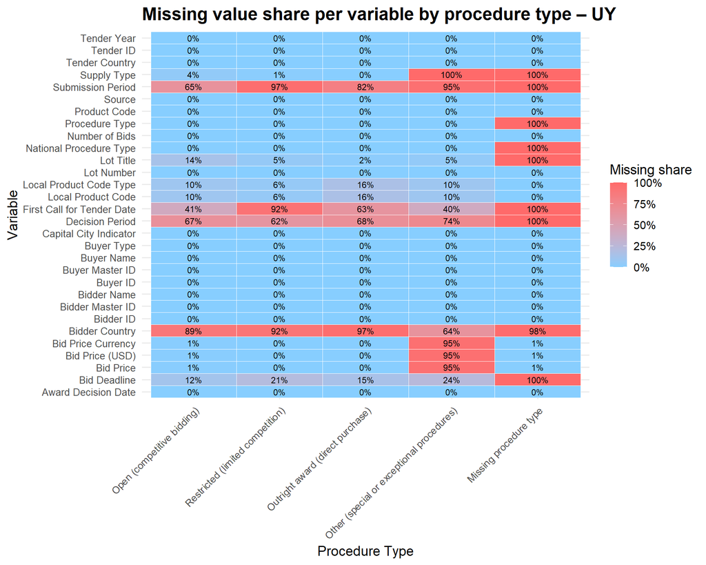

#### Trends in Missing Shares Over Time – UY

This line plot tracks how missingness evolves over time for the 10 variables with the highest average missing share. For each ‘tender_year’, the pipeline computes missingness shares for all non-indicator variables, identifies the top 10 variables with the largest average missingness, and then plots their yearly trajectories. Lines show the proportion of missing values by year for each selected variable. Use this figure to detect whether data quality is improving, deteriorating, or abruptly changing around certain years, and to identify critical breaks that might be linked to system changes, regulatory reforms, or data migration issues.

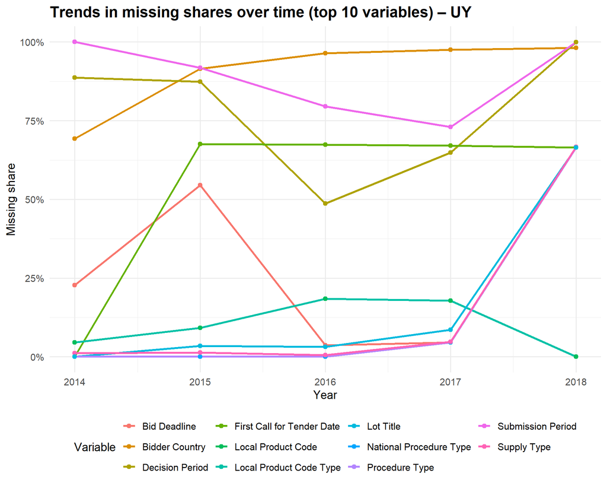

#### Missingness by Region (NUTS3) – UY

This choropleth map shows the overall share of missing values by NUTS3 region, where such information is available. The pipeline first cleans ‘buyer_nuts’ codes into valid NUTS3 identifiers, then computes the average share of missing values across all non-indicator variables for each region. These regional missingness rates are then joined to Eurostat NUTS3 geometries for the selected country (year 2021) and plotted. Regions shaded in darker colours have a higher share of missing information in buyer-level or contract-level fields. Pay attention to regions where missingness is systematically high, as this may reflect regional reporting capacity issues or gaps in how certain subnational entities interact with the procurement system.

*Figure not produced: no information or key variable is missing for the plot.*

#### Can this data be matched to other registers in the country to ensure higher quality monitoring?

The ability to match public procurement data with other registers significantly enhances the analytical power of research and strengthens auditing capabilities. Most importantly, access to company register or beneficial ownership data provides valuable insights into the supplier side—such as how long the firm has been operating, its profitability, the ratio of contract value to revenue, and how closely the procurement sector aligns with the company’s main area of activity.

In addition, linking buyers to relevant information about the government agency can greatly improve analysis on the buyer side, for instance by incorporating data on politically exposed persons or asset declarations. Finally, geospatial information can offer further insights into the location of the company or the procuring agency, enriching both analytical and oversight capacities.

#### Other types of national data available for matching

Requires manual filling

| Data type | Availability (access + format) | ID type | Comments |
| --- | --- | --- | --- |
| Company register | Open / restricted / paid + file format | Tax ID / other national ID / BvD ID | Can be used as external validation source |
| Beneficial ownership data | Open / restricted / paid + file format | Tax ID / other national ID / BvD ID | Can share data per requested list of companies |
| Asset and interest declarations | Open / restricted / paid + file format | Name of politician / Personal Tax ID / other | Often requires manual collection or scraping |

#### Case-specific analysis – matching rate between data sources

Can be filled when respective data is available

| Dataset A | Dataset B | Identifier | Matching rate |
| --- | --- | --- | --- |
| Procurement | Company register | Supplier ID + year | 0–100% |
| Company register | PEP data | Name | 0–100% |

**Source:** Contract-level data; company register records; other micro data

#### Interoperability potential at organization level

| Organization type | ID type | Missing share |
| --- | --- | --- |
| Supplier | Source ID | 0% |
| Supplier | Generated ID | 0% |
| Supplier | Name | 0% |
| Supplier | Address (postcode) | Not available (variable missing in dataset) |
| Buyer | Source ID | 0% |
| Buyer | Generated ID | 0% |
| Buyer | Name | 0% |
| Buyer | Address (postcode) | Not available (variable missing in dataset) |

#### Do companies winning contracts have risky profiles?

This analysis seeks to identify potentially suspicious patterns in company behavior, including movements between markets or registration in tax haven jurisdictions. With access to company and beneficial ownership register data, additional and more sophisticated indicators could be developed.

#### Network of Unusual Supplier Market Entries – UY

This network visualisation maps atypical movements of suppliers across CPV product clusters. Each node represents a 3-digit CPV cluster, i.e. a broad product or service market derived from ‘lot_productcode’. For every bidder, a ‘home’ CPV cluster is defined as the cluster where the bidder wins the most awards. Entries into other clusters are treated as ‘target’ markets. A bidder–cluster combination is flagged as atypical if the bidder has enough overall history, but that cluster accounts for less than 5% of their awards and at most three wins there. For each bidder–cluster pair, the pipeline computes a Laplace-smoothed probability of observing that bidder in that cluster, p(i|c) = (n_ic + 1) / (n_c + n_suppliers_c), where n_ic is the number of contracts for bidder i in cluster c, n_c is the total number of contracts in c, and n_suppliers_c is the number of distinct suppliers in c. The surprise score is then defined as -log(p(i|c)) and standardised to a z-score; higher values indicate that the bidder is unusually rare in that cluster given its overall structure. These atypical entries are aggregated at the level of home CPV cluster (source) and target CPV cluster (destination). Directed edges are drawn only for pairs of clusters where at least four distinct bidders make such atypical entries. Edge width reflects the number of bidders involved (n_bidders), and edge colour encodes the average standardised surprise score: thicker and redder edges mark flows where many suppliers enter a target market in a way that is collectively more unusual than average. Node positions are based on a force-directed layout (Fruchterman–Reingold) and help visually cluster markets that are strongly connected by unusual flows. When interpreting the figure, focus on CPV clusters with multiple thick, high-surprise edges—either as sources or as targets—as these markets may concentrate non-standard or risky supplier behaviour that merits further qualitative investigation.

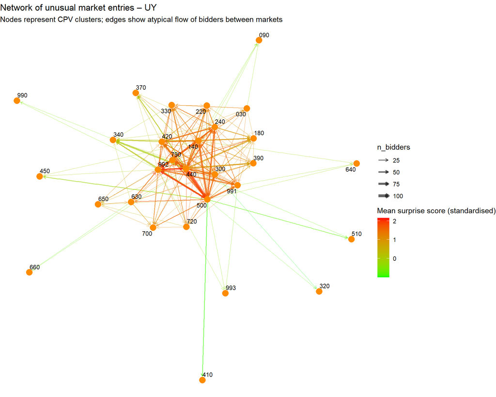

#### Suppliers with Unusually Diversified Market Entries – UY

Each bar represents a supplier flagged as behaving unusually across CPV clusters. For every bidder, the pipeline looks at all atypical CPV entries (those with high surprise z-scores) and records: the maximum surprise z-score attained across these entries, and the number of distinct target markets entered atypically. Bar height shows the maximum surprise z-score, while bar colour (if used) or additional labelling can indicate how many distinct markets each supplier enters in an unusual way. Use this figure to identify suppliers whose market expansion patterns are particularly non-standard and may warrant closer review.

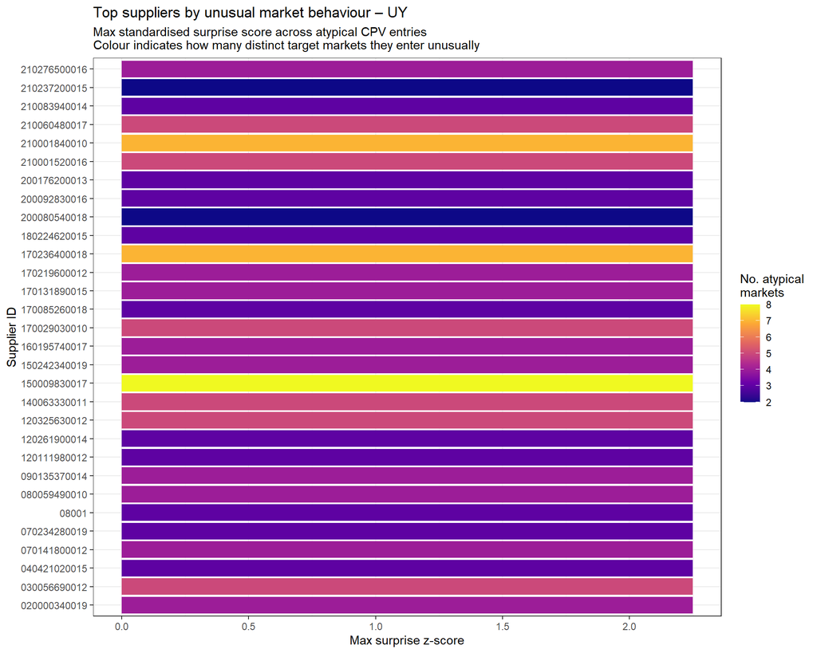

#### Markets Attracting Unusual Supplier Entries – UY

Each point represents a 3-digit CPV cluster (a broad product or service market). For each target cluster, the pipeline aggregates all atypical entries into that market and computes: (i) the number of distinct suppliers entering atypically (x-axis), (ii) the mean standardised surprise score among those entries (y-axis), and (iii) the number of atypical awards (bubble size). The resulting scatter/bubble plot highlights markets where many suppliers behave unusually (high x), where entries are particularly surprising on average (high y), or both. Clusters in the upper-right with large bubbles are markets that attract many highly atypical entries and may be especially relevant for risk-based follow-up.

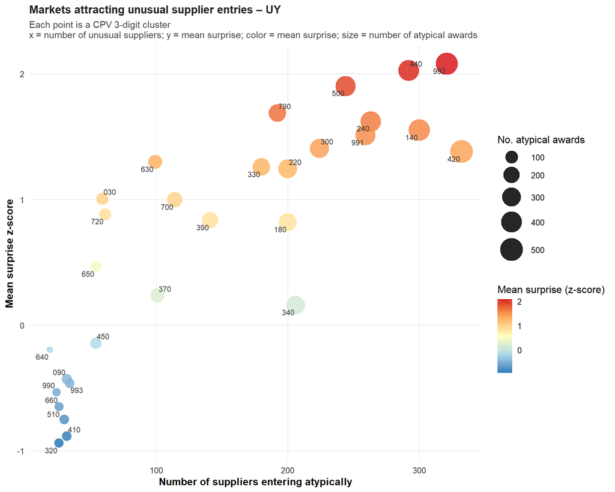

#### Are there suspicious connections between buyers and suppliers?

This analysis examines the potential existence of suspicious connections between buyers and suppliers. It can greatly benefit from access to additional registers—such as politically exposed persons (PEP) lists, interest or asset declaration databases, and beneficial ownership (BO) registers—as these can reveal direct links between suppliers and buyers.

#### Top Buyers by Supplier Concentration Over Time – UY

This faceted bar chart shows, for each year, the buyers with the highest concentration of spending on a single supplier. The pipeline groups contracts by ‘tender_year’, ‘buyer_masterid’, and ‘bidder_masterid’, computes total spend per buyer–supplier pair, and then derives, for each buyer-year, the share of spending allocated to each supplier (buyer_concentration). For buyers with at least three suppliers, the maximum of this share is used as the concentration indicator, and the top 30 buyer–year combinations per year are retained for plotting. Bars represent the maximum concentration for each buyer in a given year, labels show the number of contracts, and buyers that appear in the top list in more than one year are highlighted in red. High and persistent concentration (especially repeated red buyers across years) may signal stable and potentially problematic dependencies on single suppliers that merit closer investigation.

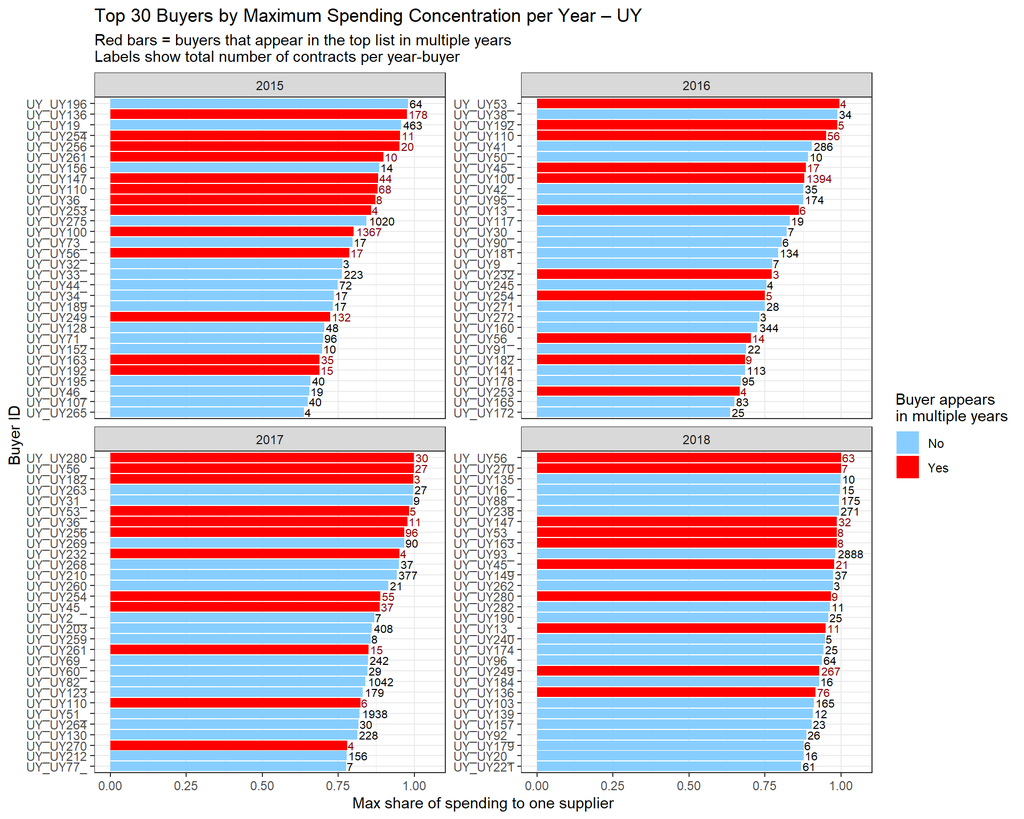

#### Is there an observable effect of transparency and integrity issues on prices and competition?

While this analysis does not establish any causal relationships, it can be used to explore correlations between transparency-related measures, prices, and competitiveness.

#### Predicted Single-Bidding by Missing Share – UY

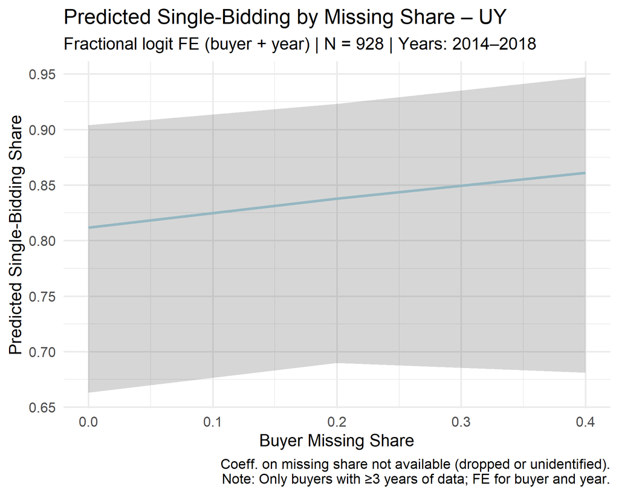

#### Predicted Relative Price by Missing Share – UY

This figure shows how relative prices correlate with overall missingness after controlling for key factors. For contracts with valid price information (bid price and estimated lot value), the pipeline computes ‘relative_price’ as bid_price / lot_estimatedprice and trims extreme or non-positive values. It then constructs ‘total_missing_share’ as the average of NA indicators across a predefined set of core variables, and estimates a linear fixed-effects model of relative_price on total_missing_share, controlling for procedure type, buyer type, and year (with year fixed effects and clustering by buyer). The line displays predicted relative prices as missingness increases, with a shaded 95% confidence interval. An upward relationship suggests that higher missingness – a proxy for weaker transparency and data quality – may be associated with higher prices relative to estimates; a flat line would indicate no clear price effect.

*Figure not produced: no information or key variable is missing for the plot.*

**Show underlying code**

```r
# ========================================================================
# Helper functions (generic utilities used by all countries)
# ========================================================================
# 0) Data uploading helper------------------------------------------------
load_data <- function(input_path) {
  data <- data.table::fread(
    input            = input_path,
    keepLeadingZeros = TRUE,
    encoding         = "UTF-8",
    stringsAsFactors = FALSE,
    showProgress     = TRUE,
    na.strings       = c("", "-", "NA")
  )

  # Drop duplicated column names (keep the first occurrence)
  dup_cols <- duplicated(names(data))
  if (any(dup_cols)) {
    data <- data[, !dup_cols, with = FALSE]
  }

  return(data)
}
# 1) Label lookup helpers ------------------------------------------------
label_with_lookup <- function(vec, lookup) {
  out <- lookup[vec]
  out[is.na(out)] <- vec[is.na(out)]
  unname(out)
}

label_lookup <- c(
  tender_id_missing_share                                  = "Tender ID",
  tender_year_missing_share                                = "Tender Year",
  lot_number_missing_share                                 = "Lot Number",
  bid_number_missing_share                                 = "Number of Bids",
  bid_iswinning_missing_share                              = "Winning Bid",
  tender_country_missing_share                             = "Tender Country",
  tender_awarddecisiondate_missing_share                   = "Award Decision Date",
  tender_contractsignaturedate_missing_share               = "Contract Signature Date",
  tender_biddeadline_missing_share                         = "Bid Deadline",
  tender_proceduretype_missing_share                       = "Procedure Type",
  tender_nationalproceduretype_missing_share               = "National Procedure Type",
  tender_supplytype_missing_share                          = "Supply Type",
  tender_publications_firstcallfortenderdate_missing_share  = "First Call for Tender Date",
  notice_url_missing_share                                 = "Notice URL",
  source_missing_share                                     = "Source",
  tender_publications_firstdcontractawarddate_missing_share = "First Contract Award Date",
  tender_publications_lastcontractawardurl_missing_share    = "Last Contract Award URL",
  buyer_masterid_missing_share                             = "Buyer Master ID",
  buyer_id_missing_share                                   = "Buyer ID",
  buyer_city_missing_share                                 = "Buyer City",
  buyer_postcode_missing_share                             = "Buyer Postcode",
  buyer_country_missing_share                              = "Buyer Country",
  buyer_nuts_missing_share                                 = "Buyer NUTS",
  buyer_name_missing_share                                 = "Buyer Name",
  buyer_buyertype_missing_share                            = "Buyer Type",
  buyer_mainactivities_missing_share                       = "Buyer Main Activities",
  tender_addressofimplementation_country_missing_share      = "Implementation Country",
  tender_addressofimplementation_nuts_missing_share         = "Implementation NUTS",
  bidder_masterid_missing_share                            = "Bidder Master ID",
  bidder_id_missing_share                                  = "Bidder ID",
  bidder_country_missing_share                             = "Bidder Country",
  bidder_nuts_missing_share                                = "Bidder NUTS",
  bidder_name_missing_share                                = "Bidder Name",
  bid_price_missing_share                                  = "Bid Price",
  bid_priceusd_missing_share                               = "Bid Price (USD)",
  bid_pricecurrency_missing_share                          = "Bid Price Currency",
  lot_productcode_missing_share                            = "Product Code",
  lot_localproductcode_type_missing_share                  = "Local Product Code Type",
  lot_localproductcode_missing_share                       = "Local Product Code",
  submp_missing_share                                      = "Submission Period",
  decp_missing_share                                       = "Decision Period",
  is_capital_missing_share                                 = "Capital City Indicator",
  lot_title_missing_share                                  = "Lot Title",
  lot_estimatedpriceusd_missing_share                      = "Estimated Price (USD)",
  lot_estimatedprice_missing_share                         = "Estimated Price",
  lot_estimatedpricecurrency_missing_share                 = "Estimated Price Currency"
)

# 2) Buyer grouping helper -----------------------------------------------
add_buyer_group <- function(buyer_buyertype) {
  group <- dplyr::case_when(
    grepl("(?i)national",  buyer_buyertype) ~ "National Buyer",
    grepl("(?i)regional",  buyer_buyertype) ~ "Regional Buyer",
    grepl("(?i)utilities", buyer_buyertype) ~ "Utilities",
    grepl("(?i)European",  buyer_buyertype) ~ "EU agency",
    TRUE                                    ~ "Other Public Bodies"
  )

  factor(
    group,
    levels = c(
      "National Buyer",
      "Regional Buyer",
      "Utilities",
      "EU agency",
      "Other Public Bodies"
    )
  )
}

# 3) Tender year helper --------------------------------------------------
add_tender_year <- function(df) {
  df %>%
    dplyr::mutate(
      tender_year = dplyr::coalesce(
        stringr::str_extract(tender_publications_firstcallfortenderdate, "^\\d{4}"),
        stringr::str_extract(tender_awarddecisiondate, "^\\d{4}"),
        stringr::str_extract(tender_biddeadline, "^\\d{4}")
      ),
      tender_year = as.integer(tender_year)
    )
}

# 4) Generic "missing shares" summariser ---------------------------------
summarise_missing_shares <- function(df, cols = !dplyr::starts_with("ind_")) {
  df %>%
    dplyr::summarise(
      dplyr::across(
        .cols  = {{ cols }},
        .fns   = ~ mean(is.na(.)),
        .names = "{.col}_missing_share"
      ),
      .groups = "drop"
    )
}
```

```r
# 5) Pivot missing shares to long format ---------------------------------
pivot_missing_long <- function(df, id_vars = NULL) {
  if (is.null(id_vars)) {
    df %>%
      tidyr::pivot_longer(
        cols      = dplyr::everything(),
        names_to  = "variable",
        values_to = "missing_share"
      )
  } else {
    df %>%
      tidyr::pivot_longer(
        cols      = -dplyr::all_of(id_vars),
        names_to  = "variable",
        values_to = "missing_share"
      )
  }
}

# 6) Generic bar plot of missing share per variable ----------------------
plot_missing_bar <- function(data_long, label_lookup, title = "Missing Value Share per Variable") {
  ggplot2::ggplot(
    data_long,
    ggplot2::aes(
      x = reorder(variable, missing_share),
      y = missing_share
    )
  ) +
    ggplot2::geom_col(fill = "lightblue") +
    ggplot2::coord_flip() +
    ggplot2::scale_x_discrete(
      labels = function(x) label_with_lookup(x, label_lookup)
    ) +
    ggplot2::labs(
      title = title,
      x     = "Variable",
      y     = "Missing Share"
    ) +
    ggplot2::theme_minimal(base_size = 16) +
    ggplot2::theme(
      plot.title = ggplot2::element_text(size = 20, face = "bold"),
      axis.title = ggplot2::element_text(size = 16),
      axis.text  = ggplot2::element_text(size = 14)
    )
}

# 7) Generic missing share heatmap -----------------------------------------
plot_missing_heatmap <- function(data, x_var, y_var, fill_var,
                                 title, x_lab, y_lab) {
  x_sym    <- rlang::sym(x_var)
  y_sym    <- rlang::sym(y_var)
  fill_sym <- rlang::sym(fill_var)

  ggplot2::ggplot(
    data,
    ggplot2::aes(
      x    = !!x_sym,
      y    = !!y_sym,
      fill = !!fill_sym
    )
  ) +
    ggplot2::geom_tile(color = "white") +
    ggplot2::geom_text(
      ggplot2::aes(label = scales::percent(!!fill_sym, accuracy = 1)),
      size  = 3,
      color = "black"
    ) +
    ggplot2::scale_fill_gradient(
      name   = "Missing share",
      labels = scales::percent_format(accuracy = 1),
      limits = c(0, 1),
      low    = "skyblue1",
      high   = "indianred1"
    ) +
    ggplot2::labs(
      title = title,
      x     = x_lab,
      y     = y_lab
    ) +
    ggplot2::theme_minimal(base_size = 14) +
    ggplot2::theme(
      plot.title  = ggplot2::element_text(size = 18, face = "bold"),
      axis.title  = ggplot2::element_text(size = 14),
      axis.text.x = ggplot2::element_text(size = 10, angle = 45, hjust = 1),
      axis.text.y = ggplot2::element_text(size = 10)
    )
}

# 8) Generic “top N bar” plot --------------------------------------------
plot_top_bar <- function(df, x_var, y_var, label_var,
                         title, x_lab, y_lab,
                         fill_color = "skyblue1",
                         y_limit   = c(0, 1.05),
                         percent   = TRUE) {
  x_sym   <- rlang::sym(x_var)
  y_sym   <- rlang::sym(y_var)
  lab_sym <- rlang::sym(label_var)

  p <- ggplot2::ggplot(
    df,
    ggplot2::aes(
      x = reorder(!!x_sym, !!y_sym),
      y = !!y_sym
    )
  ) +
    ggplot2::geom_col(fill = fill_color) +
    ggplot2::geom_text(
      ggplot2::aes(
        label = if (percent) {
          scales::percent(!!y_sym, accuracy = 0.1)
        } else {
          !!lab_sym
        }
      ),
      hjust = -0.1,
      size  = 3.2,
      check_overlap = TRUE
    ) +
    ggplot2::coord_flip() +
    ggplot2::theme_bw() +
    ggplot2::labs(
      title = title,
      x     = x_lab,
      y     = y_lab
    )

  if (!is.null(y_limit)) {
    p <- p + ggplot2::ylim(y_limit)
  }

  p
}

# 9) Generic NUTS3 cleaning helper ---------------------------------------
clean_nuts3 <- function(df, nuts_col = buyer_nuts) {
  nuts_quo <- rlang::enquo(nuts_col)

  df %>%
    dplyr::mutate(
      buyer_nuts = as.character(!!nuts_quo),
      nuts_clean = buyer_nuts %>%
        stringr::str_replace_all("\\[|\\]", "") %>%
        stringr::str_replace_all('"', "") %>%
        stringr::str_squish()
    ) %>%
    dplyr::mutate(
      # keep any valid NUTS3: two letters + three digits
      nuts3 = dplyr::if_else(
        stringr::str_detect(nuts_clean, "^[A-Z]{2}[0-9]{3}$"),
        nuts_clean,
        NA_character_
      )
    )
}

# 10) Generic ggpredict line+band plot -----------------------------------
plot_ggeffects_line <- function(pred,
                                title,
                                subtitle,
                                x_lab,
                                y_lab,
                                caption = NULL) {
  ggplot2::ggplot(pred, ggplot2::aes(x, predicted)) +
    ggplot2::geom_line(size = 1.5, color = "lightblue") +
    ggplot2::geom_ribbon(ggplot2::aes(ymin = conf.low, ymax = conf.high), alpha = 0.2) +
    ggplot2::labs(
      title    = title,
      subtitle = subtitle,
      x        = x_lab,
      y        = y_lab,
      caption  = caption
    ) +
    ggplot2::theme_minimal(base_size = 20)
}

# 11) CPV cluster df helper ----------------------------------------------
build_cpv_df <- function(df, cpv_digits = 3) {
  df %>%
    dplyr::select(
      tender_id,
      lot_number,
      bidder_id,
      lot_productcode,
      bid_priceusd
    ) %>%
    dplyr::mutate(
      cpv_cluster = stringr::str_sub(lot_productcode, 1, cpv_digits)
    )
}

# 12) Organization-level missing share for identifiers ---------------------
compute_org_missing <- function(df) {
  # helper to compute missing share safely
  miss_or_na <- function(col) {
    if (col %in% names(df)) {
      mean(is.na(df[[col]]))
    } else {
      NA_real_  # marks variable as not present
    }
  }

  tibble::tribble(
    ~organization_type, ~id_type,                                   ~missing_share,
    "Supplier",         "Source ID",                         miss_or_na("bidder_id"),
    "Supplier",         "Generated ID",                      miss_or_na("bidder_masterid"),
    "Supplier",         "Name",                              miss_or_na("bidder_name"),
    "Supplier",         "Address (postcode)",                miss_or_na("bidder_nuts"),
    "Buyer",            "Source ID",                         miss_or_na("buyer_id"),
    "Buyer",            "Generated ID",                      miss_or_na("buyer_masterid"),
    "Buyer",            "Name",                              miss_or_na("buyer_name"),
    "Buyer",            "Address (postcode)",                miss_or_na("buyer_postcode")
  )
}
```

```r
# 14) Year-filter configuration for each country and each component of the pipeline
year_filter_config <- tibble::tribble(
  ~component,  ~country_code, ~min_year, ~max_year,
  # default catch-all
  "default",   "BG",          NA,        NA,
  "default",   "UY",          NA,        NA,
  "default",   "ID",          NA,        NA,
  # component-specific overrides
  "singleb",   "BG",          2011,      2018,
  "singleb",   "UY",          2014,      NA,
  "singleb",   "ID",          2014,      NA,
  "rel_price", "BG",          2011,      2018,
  "rel_price", "UY",          2014,      NA,
  "rel_price", "ID",          NA,      NA
)


# convenient helper: returns c(min_year, max_year)
get_year_range <- function(country_code,
                           component = c("singleb", "rel_price", "default")) {
  component   <- match.arg(component)
  cc          <- toupper(country_code)

  # 1) try component-specific rule
  row_spec <- year_filter_config %>%
    dplyr::filter(component == !!component, country_code == !!cc) %>%
    dplyr::slice_head(n = 1)

  # 2) if nothing, fall back to default for that country
  if (nrow(row_spec) == 0) {
    row_spec <- year_filter_config %>%
      dplyr::filter(component == "default", country_code == !!cc) %>%
      dplyr::slice_head(n = 1)
  }

  # 3) if still nothing, fall back to "no filtering"
  if (nrow(row_spec) == 0) {
    return(list(min_year = -Inf, max_year = Inf))
  }

  min_y <- if (is.na(row_spec$min_year)) -Inf else row_spec$min_year
  max_y <- if (is.na(row_spec$max_year))  Inf else row_spec$max_year

  list(min_year = min_y, max_year = max_y)
}


# ========================================================================
# Unified country pipeline: works for any country where columns exist
# ========================================================================

run_integrity_pipeline <- function(df, country_code = "GEN", output_dir) {
  message("Running integrity pipeline for ", country_code, " ...")

  # Ensure tender_year exists for all later steps
  df <- df %>% add_tender_year()

  # ----------------------------------------------------------------------
  # SUMMARY STATS BLOCK (printed once at the beginning)
  # ----------------------------------------------------------------------
  # 1) Number of contracts per year
  n_obs_per_year <- df %>%
    dplyr::count(tender_year, name = "n_observations")

  # 2) Number of unique buyers(using buyer_masterid)
  n_unique_buyers <- if ("buyer_masterid" %in% names(df)) {
    dplyr::n_distinct(df$buyer_masterid, na.rm = TRUE)
  } else {
    NA_integer_
  }

  # 3) Number of unique tenders per year
  tender_year_tenders <- if ("tender_id" %in% names(df)) {
    df %>%
      dplyr::group_by(tender_year) %>%
      dplyr::summarise(
        n_unique_tender_id = dplyr::n_distinct(tender_id),
        .groups = "drop"
      )
  } else {
    NULL
  }

  # 4) Number of unique bidders (using bidder_masterid)
  n_unique_bidders <- if ("bidder_masterid" %in% names(df)) {
    dplyr::n_distinct(df$bidder_masterid, na.rm = TRUE)
  } else {
    NA_integer_
  }

  # 5) List of variables present (excluding ind_* variables)
  vars_present <- names(df)
  vars_present <- vars_present[!startsWith(vars_present, "ind_")]

  summary_stats <- list(
    n_obs_per_year      = n_obs_per_year,
    n_unique_buyers     = n_unique_buyers,
    tender_year_tenders = tender_year_tenders,
    n_unique_bidders    = n_unique_bidders,
    vars_present        = vars_present
  )

  cat("---------- DATA SUMMARY FOR", country_code, "----------\n\n")

  cat("Contracts per year:\n")
  print(n_obs_per_year)
  cat("\n")

  if (!is.na(n_unique_buyers)) {
    cat("Number of unique buyers (buyer_masterid): ", n_unique_buyers, "\n\n")
  } else {
    cat("Column 'buyer_masterid' not found: cannot compute number of unique buyers.\n\n")
  }

  if (!is.null(tender_year_tenders)) {
    cat("Number of unique tenders per tender_year:\n")
    print(tender_year_tenders)
    cat("\n")
  } else {
    cat("Column 'tender_id' not found: cannot compute unique tenders per year.\n\n")
  }

  if (!is.na(n_unique_bidders)) {
    cat("Number of unique bidders (bidder_masterid): ", n_unique_bidders, "\n\n")
  } else {
    cat("Column 'bidder_masterid' not found: cannot compute number of unique bidders.\n\n")
  }

  cat("Variables present (excluding indicators):\n")
  print(vars_present)
  cat("\n-----------------------------------------------\n\n")

  # ----------------------------------------------------------------------
  # Pre-initialize optional objects so they always exist (for results list)
  # ----------------------------------------------------------------------
  missing_by_buyer        <- NULL
  missing_by_buyer_plot   <- NULL
  top10_buyers_missing    <- NULL
  missing_buyers          <- NULL
  combined_buyers_plot    <- NULL
  missing_by_proc         <- NULL
  missing_by_proc_plot    <- NULL
  org_interop_missing     <- NULL

  df_cpv                  <- NULL
  unusual_matrix          <- NULL
  market_network_plot     <- NULL
  supplier_unusual        <- NULL
  supplier_unusual_plot   <- NULL
  market_unusual          <- NULL
  market_unusual_plot     <- NULL

  buyer_supplier_conc     <- NULL
  bc_overall              <- NULL
  bc_yearly               <- NULL

  buyer_missing_share     <- NULL
  buyer_singleb_rate      <- NULL
  buyer_controls          <- NULL
  buyer_analysis          <- NULL
  singleb_fe_model        <- NULL
  singleb_plot            <- NULL

  region_map_data         <- NULL
  region_missing_map      <- NULL
  missing_by_region       <- NULL

  rel_price_data          <- NULL
  rel_price_model         <- NULL
  rel_price_plot          <- NULL

  # ----------------------------------------------------------------------
  # Overall missing-value shares
  # ----------------------------------------------------------------------
  missing_shares <- df %>%
    summarise_missing_shares(cols = !dplyr::starts_with("ind_"))

  missing_shares_long <- missing_shares %>%
    pivot_missing_long()
```

```r
  missing_plot <- plot_missing_bar(
    data_long    = missing_shares_long,
    label_lookup = label_lookup,
    title        = paste("Missing Value Share per Variable –", country_code)
  )

  ggplot2::ggsave(
    filename = file.path(output_dir, paste0("missing_shares_plot_", country_code, ".png")),
    plot     = missing_plot,
    width    = 10,
    height   = 6,
    dpi      = 300
  )

  # ----------------------------------------------------------------------
  # Organization-level missing share for matching to other registers
  # ----------------------------------------------------------------------
  org_interop_missing <- compute_org_missing(df)

  # ----------------------------------------------------------------------
  # Missing shares by buyer type (if buyer_buyertype exists)
  # ----------------------------------------------------------------------
  if ("buyer_buyertype" %in% names(df)) {
    missing_by_buyer <- df %>%
      dplyr::mutate(
        buyer_group = add_buyer_group(buyer_buyertype)
      ) %>%
      dplyr::group_by(buyer_group) %>%
      summarise_missing_shares(cols = -dplyr::starts_with("ind_")) %>%
      pivot_missing_long(id_vars = "buyer_group") %>%
      dplyr::mutate(
        variable_label = label_with_lookup(variable, label_lookup)
      )

    missing_by_buyer_plot <- plot_missing_heatmap(
      data     = missing_by_buyer,
      x_var    = "buyer_group",
      y_var    = "variable_label",
      fill_var = "missing_share",
      title    = paste("Missing value share per variable by buyer type –", country_code),
      x_lab    = "Buyer type",
      y_lab    = "Variable"
    )
  }

  # ----------------------------------------------------------------------
  # Top buyers with highest overall missing share
  # ----------------------------------------------------------------------
  if (all(c("buyer_masterid", "buyer_buyertype") %in% names(df))) {
    top10_buyers_missing <- df %>%
      dplyr::select(!dplyr::starts_with("ind_")) %>%
      dplyr::group_by(buyer_masterid, buyer_buyertype) %>%
      dplyr::filter(dplyr::n() >= 100) %>%  # ADJUST: threshold for minimum obs per buyer
      dplyr::summarise(
        missing_share = mean(is.na(dplyr::cur_data_all()), na.rm = TRUE),
        .groups       = "drop"
      ) %>%
      dplyr::arrange(dplyr::desc(missing_share)) %>%
      dplyr::slice_head(n = 10) %>%
      dplyr::mutate(
        buyer_label = paste0(
          buyer_masterid, "\n",
          ifelse(is.na(buyer_buyertype), "Unknown Type", buyer_buyertype)
        ),
        buyer_label_short = dplyr::if_else(
          nchar(buyer_masterid) > 20,
          paste0(substr(buyer_masterid, 1, 20), "…\n",
                 ifelse(is.na(buyer_buyertype), "Unknown Type", buyer_buyertype)),
          buyer_label
        )
      )

    missing_buyers <- plot_top_bar(
      df        = top10_buyers_missing,
      x_var     = "buyer_label_short",  # <- show name with type below it
      y_var     = "missing_share",
      label_var = "missing_share",
      title     = paste("Top 10 buyers with highest overall missing share –", country_code),
      x_lab     = "Buyer",
      y_lab     = "Missing share",
      fill_color = "skyblue1",
      y_limit   = c(0, 1.05),
      percent   = TRUE
    )
  }



  if (!is.null(missing_by_buyer_plot) && !is.null(missing_buyers)) {
    combined_buyers_plot <- missing_by_buyer_plot + missing_buyers +
      patchwork::plot_layout(nrow = 2)

    ggplot2::ggsave(
      filename = file.path(output_dir, paste0("buyers_missing_", country_code, ".png")),
      plot     = combined_buyers_plot,
      width    = 12,
      height   = 12,
      dpi      = 300
    )
  }

  # ----------------------------------------------------------------------
  # Missing shares by procedure type (if tender_proceduretype exists)
  # ----------------------------------------------------------------------
  if ("tender_proceduretype" %in% names(df)) {

    # Define readable labels for procurement procedure types
    procedure_type_labels <- c(
      "OPEN"                           = "Open (competitive bidding)",
      "RESTRICTED"                     = "Restricted (limited competition)",
      "NEGOTIATED_WITH_PUBLICATION"    = "Negotiated with publication (limited competition)",
      "NEGOTIATED_WITHOUT_PUBLICATION" = "Negotiated without publication (no competition)",
      "NEGOTIATED"                     = "Negotiated (limited competition)",
      "COMPETITIVE_DIALOG"             = "Competitive dialogue (limited competition)",
      "OUTRIGHT_AWARD"                 = "Outright award (direct purchase)",
      "OTHER"                          = "Other (special or exceptional procedures)",
      "Missing procedure type"         = "Missing procedure type"
    )

    missing_by_proc <- df %>%
      dplyr::mutate(
        proc_group = ifelse(
          is.na(tender_proceduretype),
          "Missing procedure type",
          as.character(tender_proceduretype)
        )
      ) %>%
      dplyr::group_by(proc_group) %>%
      summarise_missing_shares(cols = -dplyr::starts_with("ind_")) %>%
      pivot_missing_long(id_vars = "proc_group") %>%
      dplyr::mutate(
        proc_group_label = ifelse(
          proc_group %in% names(procedure_type_labels),
          procedure_type_labels[proc_group],
          proc_group
        ),
        variable_label   = label_with_lookup(variable, label_lookup),
        proc_group_label = factor(
          proc_group_label,
          levels = c(
            "Open (competitive bidding)",
            "Restricted (limited competition)",
            "Negotiated with publication (limited competition)",
            "Negotiated without publication (no competition)",
            "Negotiated (limited competition)",
            "Competitive dialogue (limited competition)",
            "Outright award (direct purchase)",
            "Other (special or exceptional procedures)",
            "Missing procedure type"
          )
        )
      )

    missing_by_proc_plot <- plot_missing_heatmap(
      data     = missing_by_proc,
      x_var    = "proc_group_label",
      y_var    = "variable_label",
      fill_var = "missing_share",
      title    = paste("Missing value share per variable by procedure type –", country_code),
      x_lab    = "Procedure Type",
      y_lab    = "Variable"
    )
```

```r
    ggplot2::ggsave(
      filename = file.path(output_dir, paste0("missing_by_proc_", country_code, ".png")),
      plot     = missing_by_proc_plot,
      width    = 10,
      height   = 6,
      dpi      = 300
    )
  }


  # ----------------------------------------------------------------------
  # Correlation of missing share across variables
  # ----------------------------------------------------------------------
  miss_matrix <- df %>%
    dplyr::select(!dplyr::starts_with("ind_")) %>%
    dplyr::mutate(dplyr::across(dplyr::everything(), ~ as.numeric(is.na(.))))

  miss_corr <- corrr::correlate(miss_matrix)

  miss_corr_long <- miss_corr %>%
    corrr::stretch(na.rm = TRUE)

  corr_plot <- ggplot2::ggplot(
    miss_corr_long,
    ggplot2::aes(
      x    = x,
      y    = y,
      fill = r
    )
  ) +
    ggplot2::geom_tile() +
    ggplot2::scale_fill_gradient2(
      low      = "blue",
      mid      = "white",
      high     = "red",
      midpoint = 0,
      limits   = c(-1, 1)
    ) +
    ggplot2::coord_equal() +
    ggplot2::labs(
      title = paste("Correlation of NAs across variables –", country_code),
      x     = "Variable",
      y     = "Variable",
      fill  = "Correlation"
    ) +
    ggplot2::theme_minimal(base_size = 12) +
    ggplot2::theme(
      axis.text.x = ggplot2::element_text(angle = 90, vjust = 0.5, hjust = 1)
    )

  ggplot2::ggsave(
    filename = file.path(output_dir, paste0("missing_corr_", country_code, ".png")),
    plot     = corr_plot,
    width    = 10,
    height   = 8,
    dpi      = 300
  )

  miss_corr_top <- miss_corr_long %>%
    dplyr::filter(x != y) %>%
    dplyr::arrange(dplyr::desc(abs(r))) %>%
    dplyr::slice_head(n = 20)
  # NOTE: no longer printed; just stored in results

  # ----------------------------------------------------------------------
  # Missing shares over time (by tender year)
  # ----------------------------------------------------------------------
  missing_by_year <- df %>%
    dplyr::filter(!is.na(tender_year)) %>%
    dplyr::group_by(tender_year) %>%
    summarise_missing_shares(cols = !dplyr::starts_with("ind_")) %>%
    pivot_missing_long(id_vars = "tender_year") %>%
    dplyr::mutate(
      variable_label = label_with_lookup(variable, label_lookup)
    )

  top_vars <- missing_by_year %>%
    dplyr::group_by(variable_label) %>%
    dplyr::summarise(
      avg_missing = mean(missing_share, na.rm = TRUE),
      .groups     = "drop"
    ) %>%
    dplyr::slice_max(avg_missing, n = 10) %>%
    dplyr::pull(variable_label)

  year_miss <- missing_by_year %>%
    dplyr::filter(variable_label %in% top_vars) %>%
    ggplot2::ggplot(
      ggplot2::aes(
        x     = tender_year,
        y     = missing_share,
        color = variable_label
      )
    ) +
    ggplot2::geom_line(size = 1.2) +
    ggplot2::geom_point(size = 2) +
    ggplot2::scale_y_continuous(labels = scales::percent_format(accuracy = 1)) +
    ggplot2::labs(
      title = paste("Trends in missing shares over time (top 10 variables) –", country_code),
      x     = "Year",
      y     = "Missing share",
      color = "Variable"
    ) +
    ggplot2::theme_minimal(base_size = 14) +
    ggplot2::theme(
      plot.title      = ggplot2::element_text(size = 18, face = "bold"),
      legend.position = "bottom"
    )

  ggplot2::ggsave(
    filename = file.path(output_dir, paste0("year_miss_", country_code, ".png")),
    plot     = year_miss,
    width    = 10,
    height   = 6,
    dpi      = 300
  )

  # ----------------------------------------------------------------------
  # Unusual supplier market entries by CPV cluster (if columns exist)
  # ----------------------------------------------------------------------
  if (all(c("tender_id", "lot_number", "bidder_id", "lot_productcode", "bid_priceusd") %in% names(df))) {

    df_cpv <- build_cpv_df(df, cpv_digits = 3)  # ADJUST cpv_digits (2,3,4...)

    bidder_cpv_stats <- df_cpv %>%
      dplyr::group_by(bidder_id, cpv_cluster) %>%
      dplyr::summarise(
        n_awards    = dplyr::n(),
        total_value = sum(bid_priceusd, na.rm = TRUE),
        .groups     = "drop"
      ) %>%
      dplyr::group_by(bidder_id) %>%
      dplyr::mutate(
        bidder_total_awards = sum(n_awards),
        bidder_total_value  = sum(total_value),
        share_awards        = n_awards / bidder_total_awards,
        share_value         = ifelse(
          bidder_total_value > 0,
          total_value / bidder_total_value,
          NA_real_
        )
      ) %>%
      dplyr::ungroup()

    df_with_flags <- df_cpv %>%
      dplyr::left_join(
        bidder_cpv_stats %>%
          dplyr::select(
            bidder_id,
            cpv_cluster,
            n_awards,
            bidder_total_awards,
            share_awards,
            share_value
          ),
        by = c("bidder_id", "cpv_cluster")
      ) %>%
      dplyr::mutate(
        enough_history   = bidder_total_awards >= 4,  # ADJUST: history threshold
        cpv_cluster_atypical =
          enough_history &
          share_awards < 0.05 &                       # ADJUST: marginal share
          n_awards <= 3                               # ADJUST: max wins in atypical cluster
      )

    cluster_supplier_counts <- df_cpv %>%
      dplyr::group_by(cpv_cluster, bidder_id) %>%
      dplyr::summarise(
        n_ic   = dplyr::n(),
        .groups = "drop"
      )

    cluster_totals <- df_cpv %>%
      dplyr::group_by(cpv_cluster) %>%
      dplyr::summarise(
        n_c           = dplyr::n(),
        n_suppliers_c = dplyr::n_distinct(bidder_id),
        .groups       = "drop"
      )

    cluster_surprise <- cluster_supplier_counts %>%
      dplyr::left_join(cluster_totals, by = "cpv_cluster") %>%
      dplyr::mutate(
        p_i_given_c    = (n_ic + 1) / (n_c + n_suppliers_c),  # Laplace smoothing
        surprise_score = -log(p_i_given_c)
      )

    df_with_surprise <- df_with_flags %>%
      dplyr::left_join(
        cluster_surprise %>%
          dplyr::select(cpv_cluster, bidder_id, surprise_score),
        by = c("cpv_cluster", "bidder_id")
      ) %>%
      dplyr::mutate(
        surprise_z = ifelse(
          !is.na(surprise_score),
          (surprise_score - mean(surprise_score, na.rm = TRUE)) /
            sd(surprise_score, na.rm = TRUE),
          NA_real_
        )
      )
```

```r
    home_market <- bidder_cpv_stats %>%
      dplyr::group_by(bidder_id) %>%
      dplyr::slice_max(n_awards, n = 1, with_ties = FALSE) %>%
      dplyr::ungroup() %>%
      dplyr::transmute(
        bidder_id,
        home_cpv_cluster = cpv_cluster
      )

    df_unusual <- df_with_surprise %>%
      dplyr::left_join(home_market, by = "bidder_id") %>%
      dplyr::mutate(target_cpv_cluster = cpv_cluster) %>%
      dplyr::filter(
        enough_history,
        cpv_cluster_atypical,
        !is.na(surprise_z)
      )

    unusual_matrix <- df_unusual %>%
      dplyr::group_by(home_cpv_cluster, target_cpv_cluster) %>%
      dplyr::summarise(
        n_bidders     = dplyr::n_distinct(bidder_id),
        n_awards      = dplyr::n(),
        mean_surprise = mean(surprise_z, na.rm = TRUE),
        .groups       = "drop"
      )

    edges_markets <- unusual_matrix %>%
      dplyr::filter(n_bidders >= 4) %>%  # ADJUST: min number of bidders for edge
      dplyr::rename(
        from = home_cpv_cluster,
        to   = target_cpv_cluster
      )

    if (nrow(edges_markets) > 0) {
      g_markets <- igraph::graph_from_data_frame(edges_markets, directed = TRUE)

      market_network_plot <- ggraph::ggraph(g_markets, layout = "fr") +
        ggraph::geom_edge_link(
          ggplot2::aes(width = n_bidders, colour = mean_surprise),
          arrow   = grid::arrow(length = grid::unit(0.15, "cm")),
          end_cap = ggraph::circle(2, "mm"),
          alpha   = 0.6
        ) +
        ggraph::geom_node_point(size = 4, colour = "darkorange") +
        ggraph::geom_node_text(ggplot2::aes(label = name), repel = TRUE, size = 3) +
        ggraph::scale_edge_width(range = c(0.2, 2)) +
        ggraph::scale_edge_colour_continuous(
          low  = "green",
          high = "red",
          name = "Mean surprise score (standardised)"
        ) +
        ggplot2::labs(
          title    = paste("Network of unusual market entries –", country_code),
          subtitle = "Nodes represent CPV clusters; edges show atypical flow of bidders between markets"
        ) +
        ggplot2::theme_void()

      ggplot2::ggsave(
        filename = file.path(output_dir, paste0("supp_net_", country_code, ".png")),
        plot     = market_network_plot,
        width    = 10,
        height   = 6,
        dpi      = 300
      )
    } else {
      message("No edges for unusual market entries network (", country_code, ").")
    }
  }

  # ------------------------------------------------------------------
  # Supplier / market unusualness (only if df_unusual exists)
  # ------------------------------------------------------------------
  if (exists("df_unusual") && !is.null(df_unusual) && nrow(df_unusual) > 0) {

    # Supplier-level "unusualness": who behaves strangely?
    supplier_unusual <- df_unusual %>%
      dplyr::group_by(bidder_id, home_cpv_cluster) %>%
      dplyr::summarise(
        max_surprise_z      = max(surprise_z, na.rm = TRUE),
        mean_surprise_z     = mean(surprise_z, na.rm = TRUE),
        n_atypical_markets  = dplyr::n_distinct(target_cpv_cluster),
        n_atypical_awards   = dplyr::n(),
        .groups             = "drop"
      )

    # focus on the most "interesting" suppliers (adjust thresholds as needed)
    top_suppliers <- supplier_unusual %>%
      dplyr::filter(n_atypical_awards >= 3) %>%         # at least 3 atypical awards
      dplyr::arrange(dplyr::desc(max_surprise_z)) %>%
      dplyr::slice_head(n = 30)                         # top 30 by max surprise

    supplier_unusual_plot <- ggplot2::ggplot(
      top_suppliers,
      ggplot2::aes(
        x = reorder(bidder_id, max_surprise_z),
        y = max_surprise_z,
        fill = n_atypical_markets
      )
    ) +
      ggplot2::geom_col() +
      ggplot2::coord_flip() +
      ggplot2::scale_fill_viridis_c(
        option = "C",
        name   = "No. atypical\nmarkets"
      ) +
      ggplot2::labs(
        title    = paste("Top suppliers by unusual market behaviour –", country_code),
        subtitle = "Max standardised surprise score across atypical CPV entries\nColour indicates how many distinct target markets they enter unusually",
        x        = "Supplier ID",
        y        = "Max surprise z-score"
      ) +
      ggplot2::theme_bw(base_size = 11)

    ggplot2::ggsave(
      filename = file.path(output_dir, paste0("supp_unusual_suppliers_", country_code, ".png")),
      plot     = supplier_unusual_plot,
      width    = 9,
      height   = 7,
      dpi      = 300
    )

    # Market-level "unusualness": which CPV clusters attract unusual entries?
    market_unusual <- df_unusual %>%
      dplyr::group_by(target_cpv_cluster) %>%
      dplyr::summarise(
        mean_surprise_z      = mean(surprise_z, na.rm = TRUE),
        max_surprise_z       = max(surprise_z, na.rm = TRUE),
        n_unusual_suppliers  = dplyr::n_distinct(bidder_id),
        n_unusual_awards     = dplyr::n(),
        .groups              = "drop"
      ) %>%
      dplyr::mutate(
        market_risk_index = mean_surprise_z * log1p(n_unusual_suppliers)
      )

    top_markets <- market_unusual %>%
      dplyr::slice_max(market_risk_index, n = 30)

    market_unusual_plot <- ggplot2::ggplot(
      top_markets,
      ggplot2::aes(
        x = n_unusual_suppliers,
        y = mean_surprise_z,
        size = n_unusual_awards,
        colour = mean_surprise_z,
        label = target_cpv_cluster
      )
    ) +
      ggplot2::geom_point(alpha = 0.85) +
      ggrepel::geom_text_repel(size = 3, colour = "gray20") +
      ggplot2::scale_size_continuous(
        name = "No. atypical awards",
        range = c(3, 12)
      ) +
      ggplot2::scale_colour_gradientn(
        colours = c("#2c7bb6", "#abd9e9", "#ffffbf", "#fdae61", "#d7191c"),
        name = "Mean surprise (z-score)",
        limits = c(min(top_markets$mean_surprise_z, na.rm = TRUE),
                   max(top_markets$mean_surprise_z, na.rm = TRUE))
      ) +
      ggplot2::labs(
        title    = paste("Markets attracting unusual supplier entries –", country_code),
        subtitle = "Each point is a CPV 3-digit cluster\nx = number of unusual suppliers; y = mean surprise; color = mean surprise; size = number of atypical awards",
        x        = "Number of suppliers entering atypically",
        y        = "Mean surprise z-score"
      ) +
      ggplot2::theme_minimal(base_size = 12) +
      ggplot2::theme(
        plot.title      = ggplot2::element_text(face = "bold", size = 13, colour = "#222222"),
        plot.subtitle   = ggplot2::element_text(size = 11, colour = "#444444"),
        legend.position = "right",
        panel.grid.minor = ggplot2::element_blank(),
        panel.grid.major = ggplot2::element_line(colour = "grey85", linewidth = 0.3),
        axis.title      = ggplot2::element_text(face = "bold"),
        axis.text       = ggplot2::element_text(colour = "#333333")
      )
```

```r
    ggplot2::ggsave(
      filename = file.path(output_dir, paste0("supp_unusual_markets_", country_code, ".png")),
      plot     = market_unusual_plot,
      width    = 9,
      height   = 7,
      dpi      = 300
    )

  } else {
    # keep these NULL so the results list is consistent
    supplier_unusual      <- NULL
    supplier_unusual_plot <- NULL
    market_unusual        <- NULL
    market_unusual_plot   <- NULL
  }

  # ----------------------------------------------------------------------
  # Buyer–supplier concentration (overall and by year)
  # ----------------------------------------------------------------------
  if (all(c("buyer_masterid", "bidder_masterid", "bid_priceusd") %in% names(df))) {
    buyer_supplier_conc <- df %>%
      dplyr::group_by(tender_year, buyer_masterid, bidder_masterid) %>%
      dplyr::summarise(
        n_contracts = dplyr::n(),
        total_spend = sum(bid_priceusd, na.rm = TRUE),
        .groups     = "drop"
      ) %>%
      dplyr::group_by(tender_year, buyer_masterid) %>%
      dplyr::mutate(
        buyer_total_spend    = sum(total_spend, na.rm = TRUE),
        buyer_total_contract = dplyr::n(),
        buyer_concentration  = ifelse(
          buyer_total_spend > 0,
          total_spend / buyer_total_spend,
          NA_real_
        )
      ) %>%
      dplyr::ungroup()

    buyer_supplier_conc <- buyer_supplier_conc %>%
      dplyr::group_by(tender_year, buyer_masterid) %>%
      dplyr::mutate(
        n_suppliers                 = dplyr::n(),
        buyer_concentration_display = ifelse(
          n_suppliers < 3, NA_real_, buyer_concentration  # ADJUST: min suppliers
        )
      ) %>%
      dplyr::ungroup() %>%
      tidyr::drop_na()

    top_buyers <- buyer_supplier_conc %>%
      dplyr::group_by(buyer_masterid) %>%
      dplyr::summarise(
        max_conc        = max(buyer_concentration_display, na.rm = TRUE),
        total_contracts = sum(n_contracts, na.rm = TRUE),
        .groups         = "drop"
      ) %>%
      dplyr::slice_max(max_conc, n = 50)

    bc_overall <- ggplot2::ggplot(
      top_buyers,
      ggplot2::aes(
        x = reorder(buyer_masterid, max_conc),
        y = max_conc
      )
    ) +
      ggplot2::geom_col(fill = "skyblue1") +
      ggplot2::geom_text(
        ggplot2::aes(label = total_contracts),
        hjust = -0.1,
        size  = 3.2
      ) +
      ggplot2::coord_flip() +
      ggplot2::scale_x_discrete(
        labels = function(x) substr(x, 1, 8)
      ) +
      ggplot2::theme_bw() +
      ggplot2::labs(
        title    = paste("Top 50 Buyers by Maximum Supplier Concentration –", country_code),
        subtitle = "Labels show total number of contracts procured by buyer",
        x        = "Buyer ID",
        y        = "Max share of spending to one supplier"
      ) +
      ggplot2::ylim(0, 1.05)

    ggplot2::ggsave(
      filename = file.path(output_dir, paste0("bc_overall_", country_code, ".png")),
      plot     = bc_overall,
      width    = 10,
      height   = 8,
      dpi      = 300
    )

    top_buyers_yearly <- buyer_supplier_conc %>%
      dplyr::filter(tender_year > 2014) %>%  # ADJUST: year cutoff
      dplyr::group_by(tender_year, buyer_masterid) %>%
      dplyr::summarise(
        max_conc        = max(buyer_concentration_display, na.rm = TRUE),
        total_contracts = sum(n_contracts, na.rm = TRUE),
        .groups         = "drop"
      ) %>%
      dplyr::group_by(tender_year) %>%
      dplyr::slice_max(max_conc, n = 30) %>%  # ADJUST: top N buyers per year
      dplyr::ungroup()

    repeated_buyers <- top_buyers_yearly %>%
      dplyr::count(buyer_masterid) %>%
      dplyr::filter(n > 1) %>%
      dplyr::transmute(buyer_masterid, repeated = TRUE)

    top_buyers_yearly <- top_buyers_yearly %>%
      dplyr::left_join(repeated_buyers, by = "buyer_masterid") %>%
      dplyr::mutate(repeated = dplyr::if_else(is.na(repeated), FALSE, repeated))

    bc_yearly <- ggplot2::ggplot(
      top_buyers_yearly,
      ggplot2::aes(
        x     = tidytext::reorder_within(buyer_masterid, max_conc, tender_year),
        y     = max_conc,
        fill  = repeated
      )
    ) +
      ggplot2::geom_col() +
      ggplot2::geom_text(
        ggplot2::aes(label = total_contracts, color = repeated),
        hjust       = -0.1,
        size        = 2.8,
        show.legend = FALSE
      ) +
      ggplot2::coord_flip() +
      ggplot2::facet_wrap(~ tender_year, scales = "free_y") +
      tidytext::scale_x_reordered(
        labels = function(x) substr(x, 1, 8)
      ) +
      ggplot2::scale_fill_manual(
        values = c(`FALSE` = "skyblue1", `TRUE` = "red"),
        name   = "Buyer appears\nin multiple years",
        labels = c("No", "Yes")
      ) +
      ggplot2::scale_color_manual(
        values = c(`FALSE` = "black", `TRUE` = "red4")
      ) +
      ggplot2::theme_bw(base_size = 11) +
      ggplot2::labs(
        title    = paste("Top 30 Buyers by Maximum Spending Concentration per Year –", country_code),
        subtitle = "Red bars = buyers that appear in the top list in multiple years\nLabels show total number of contracts per year-buyer",
        x        = "Buyer ID",
        y        = "Max share of spending to one supplier"
      ) +
      ggplot2::ylim(0, 1.05)

    ggplot2::ggsave(
      filename = file.path(output_dir, paste0("bc_yearly_", country_code, ".png")),
      plot     = bc_yearly,
      width    = 10,
      height   = 8,
      dpi      = 300
    )
  }

  # ----------------------------------------------------------------------
  # Effect of non-transparency on competition (FE regression)
  # ----------------------------------------------------------------------
  if ("ind_corr_singleb" %in% names(df)) {

    df <- df %>%
      dplyr::mutate(
        ind_corr_singleb = dplyr::if_else(
          !is.na(ind_corr_singleb),
          ind_corr_singleb / 100,
          NA_real_
        )
      )

    # ---- Country-specific year filter ------------------------------
    yr <- get_year_range(country_code, component = "singleb")
```

```r
    df_filtered <- df %>%
      dplyr::filter(
        !is.na(tender_year),
        tender_year >= yr$min_year,
        tender_year <= yr$max_year
      )

    if (nrow(df_filtered) == 0L) {
      message("No observations after year filter for ", country_code, " (singleb).")
      singleb_fe_model <- NULL
      singleb_plot     <- NULL

    } else {

      # --- Compute missing-share indicator per buyer-year -------------
      buyer_missing_share <- df_filtered %>%
        dplyr::group_by(buyer_masterid, tender_year) %>%
        summarise_missing_shares(cols = !dplyr::starts_with("ind_")) %>%
        dplyr::mutate(
          cumulative_missing_share = rowMeans(
            dplyr::across(dplyr::ends_with("_missing_share")),
            na.rm = TRUE
          )
        )

      # --- Compute single-bidding share per buyer-year ----------------
      buyer_singleb_rate <- df_filtered %>%
        dplyr::group_by(buyer_masterid, tender_year) %>%
        dplyr::summarise(
          cumulative_singleb_rate = mean(ind_corr_singleb, na.rm = TRUE),
          .groups = "drop"
        )

      # --- Basic controls ---------------------------------------------
      buyer_controls <- df_filtered %>%
        dplyr::group_by(buyer_masterid, tender_year, buyer_buyertype) %>%
        dplyr::summarise(
          n_contracts          = dplyr::n(),
          avg_contract_value   = mean(bid_priceusd, na.rm = TRUE),
          total_contract_value = sum(bid_priceusd, na.rm = TRUE),
          .groups              = "drop"
        )

      # --- Merge datasets ---------------------------------------------
      buyer_analysis <- buyer_missing_share %>%
        dplyr::select(buyer_masterid, tender_year, cumulative_missing_share) %>%
        dplyr::inner_join(buyer_singleb_rate, by = c("buyer_masterid", "tender_year")) %>%
        dplyr::inner_join(buyer_controls,     by = c("buyer_masterid", "tender_year")) %>%
        dplyr::mutate(
          buyer_buyertype = forcats::fct_explicit_na(as.factor(buyer_buyertype), "Unknown")
        )

      # --- Keep only buyers with >=3 distinct years ----------------
      buyer_year_span <- buyer_analysis %>%
        dplyr::group_by(buyer_masterid) %>%
        dplyr::summarise(
          n_years = dplyr::n_distinct(tender_year),
          .groups = "drop"
        )

      eligible_buyers <- buyer_year_span %>%
        dplyr::filter(n_years >= 3L) %>%
        dplyr::pull(buyer_masterid)

      buyer_analysis_fe <- buyer_analysis %>%
        dplyr::filter(buyer_masterid %in% eligible_buyers)

      if (nrow(buyer_analysis_fe) == 0L) {
        message("No buyers with ≥3 years of data for ", country_code, " (singleb).")
        singleb_fe_model <- NULL
        singleb_plot     <- NULL

      } else {
        # --- FE model: buyer + year fixed effects -------------------
        singleb_fe_model <- fixest::feglm(
          cumulative_singleb_rate ~ cumulative_missing_share +
            log1p(n_contracts) +
            log1p(avg_contract_value) |
            buyer_masterid + tender_year,
          family = quasibinomial(link = "logit"),
          data   = buyer_analysis_fe
        )

        # --- Extract summary info SAFELY ----------------------------
        model_sum <- summary(singleb_fe_model)
        n_obs     <- model_sum$nobs

        coef_df <- as.data.frame(model_sum$coeftable)

        # default values if the coefficient is not in the table
        coef_est <- NA_real_
        coef_p   <- NA_real_
        stars    <- ""

        if ("cumulative_missing_share" %in% rownames(coef_df)) {
          coef_row <- coef_df["cumulative_missing_share", , drop = FALSE]

          # protect against numeric(0)
          if (nrow(coef_row) == 1L) {
            coef_est <- as.numeric(coef_row$Estimate)
            coef_p   <- as.numeric(coef_row$`Pr(>|z|)`)

            # significance stars – only if coef_p is a single non-NA number
            if (!is.na(coef_p) && length(coef_p) == 1L) {
              if (coef_p < 0.001) {
                stars <- "***"
              } else if (coef_p < 0.01) {
                stars <- "**"
              } else if (coef_p < 0.05) {
                stars <- "*"
              } else {
                stars <- ""
              }
            }
          }
        }

        year_min <- min(buyer_analysis_fe$tender_year, na.rm = TRUE)
        year_max <- max(buyer_analysis_fe$tender_year, na.rm = TRUE)

        # --- Model text for plot ------------------------------------
        model_subtitle <- sprintf(
          "Fractional logit FE (buyer + year) | N = %s | Years: %s–%s",
          formatC(n_obs, big.mark = ",", format = "f", digits = 0),
          year_min,
          year_max
        )

        if (isTRUE(!is.na(coef_est) && length(coef_est) == 1L && !is.na(coef_p))) {
          model_caption <- sprintf(
            "Coeff. on missing share: %.3f%s (p = %.3f)\nNote: Only buyers with ≥3 years of data; FE for buyer and year.",
            coef_est,
            stars,
            coef_p
          )
        } else {
          model_caption <- "Coeff. on missing share not available (dropped or unidentified).\nNote: Only buyers with ≥3 years of data; FE for buyer and year."
        }

        # --- Predicted relationship plot (with guard) ---------------
        pred_singleb <- tryCatch(
          ggeffects::ggpredict(
            singleb_fe_model,
            terms = "cumulative_missing_share"
          ),
          error = function(e) {
            message("ggpredict failed for ", country_code, " (singleb): ", e$message)
            NULL
          }
        )

        if (is.null(pred_singleb)) {
          singleb_plot <- NULL
        } else {
          singleb_plot <- plot_ggeffects_line(
            pred      = pred_singleb,
            title     = paste("Predicted Single-Bidding by Missing Share –", country_code),
            subtitle  = model_subtitle,
            x_lab     = "Buyer Missing Share",
            y_lab     = "Predicted Single-Bidding Share",
            caption   = model_caption
          )
```

```r
          ggplot2::ggsave(
            filename = file.path(output_dir, paste0("reg_singleb_missing_share_", country_code, ".png")),
            plot     = singleb_plot,
            width    = 10,
            height   = 8,
            dpi      = 300
          )
        }
      }
    }
  }

  # ----------------------------------------------------------------------
  # Region-level missing share map (NUTS3-style; mainly EU)
  # ----------------------------------------------------------------------
  if ("buyer_nuts" %in% names(df)) {
    df_nuts <- df %>%
      clean_nuts3(buyer_nuts)

    # (no more print(table(...)) here)

    missing_by_region <- df_nuts %>%
      dplyr::filter(!is.na(nuts3)) %>%
      dplyr::select(!dplyr::starts_with("ind_")) %>%
      dplyr::group_by(nuts3) %>%
      dplyr::summarise(
        missing_share = mean(is.na(dplyr::cur_data_all()), na.rm = TRUE),
        .groups       = "drop"
      )

    region_sf <- eurostat::get_eurostat_geospatial(
      output_class = "sf",
      nuts_level   = 3,
      year         = 2021
    ) %>%
      dplyr::filter(CNTR_CODE == country_code)

    region_map_data <- region_sf %>%
      dplyr::left_join(missing_by_region, by = c("NUTS_ID" = "nuts3"))

    region_missing_map <- ggplot2::ggplot(region_map_data) +
      ggplot2::geom_sf(ggplot2::aes(fill = missing_share), color = "grey40", size = 0.2) +
      ggplot2::scale_fill_distiller(
        palette   = "Blues",
        direction = 1,
        na.value  = "grey90",
        labels    = scales::percent_format(accuracy = 1),
        name      = "Missing share"
      ) +
      ggplot2::labs(
        title = paste("Overall share of missing values by region (NUTS3) –", country_code)
      ) +
      ggplot2::theme_minimal()

    ggplot2::ggsave(
      filename = file.path(output_dir, paste0("region_missing_map_", country_code, ".png")),
      plot     = region_missing_map,
      width    = 10,
      height   = 6,
      dpi      = 300
    )
  }

  # ----------------------------------------------------------------------
  # Effect on relative price (generic), if price variables exist
  # ----------------------------------------------------------------------
  if (all(c("bid_price", "lot_estimatedprice") %in% names(df))) {
    key_vars <- names(label_lookup) %>%
      gsub("_missing_share", "", .)

    df <- df %>%
      dplyr::mutate(
        total_missing_share = rowMeans(
          dplyr::across(all_of(key_vars), ~ is.na(.)),
          na.rm = TRUE
        )
      )

    # --- NEW: country- and component-specific year filter -------------
    yr <- get_year_range(country_code, component = "rel_price")

    rel_price_data <- df %>%
      dplyr::mutate(
        relative_price = bid_price / lot_estimatedprice,
        relative_price = ifelse(
          relative_price > 5 | relative_price <= 0,
          NA,
          relative_price
        )
      ) %>%
      dplyr::filter(
        !is.na(tender_year),
        tender_year >= yr$min_year,
        tender_year <= yr$max_year
      )
    # ------------------------------------------------------------------

    if ("tender_proceduretype" %in% names(rel_price_data)) {
      rel_price_data <- rel_price_data %>%
        dplyr::mutate(
          tender_proceduretype = stats::relevel(
            as.factor(tender_proceduretype),
            ref = "OPEN"
          )
        )
    }
    if ("buyer_buyertype" %in% names(rel_price_data)) {
      rel_price_data <- rel_price_data %>%
        dplyr::mutate(
          buyer_buyertype = stats::relevel(
            as.factor(buyer_buyertype),
            ref = "UTILITIES"
          )
        )
    }

    rel_price_model <- fixest::feols(
      relative_price ~ total_missing_share +
        buyer_buyertype +
        tender_proceduretype |
        tender_year,
      data    = rel_price_data,
      cluster = ~ buyer_masterid
    )

    pred_price <- ggeffects::ggpredict(rel_price_model, terms = "total_missing_share")

    rel_price_plot <- plot_ggeffects_line(
      pred      = pred_price,
      title     = paste("Predicted Relative Price by Missing Share –", country_code),
      subtitle  = "Linear model with year FE (SEs clustered by buyer)\nControls: procedure type, tender year, buyer type",
      x_lab     = "Total Missing Share",
      y_lab     = "Predicted Relative Price",
      caption   = "Note: predicted relative price per contract.\nShaded area = 95% confidence interval (clustered by buyer)."
    )

    ggplot2::ggsave(
      filename = file.path(output_dir, paste0("reg_relative_price_missing_share_", country_code, ".png")),
      plot     = rel_price_plot,
      width    = 10,
      height   = 8,
      dpi      = 300
    )
  }

  # ----------------------------------------------------------------------
  # Collect outputs to return (data + plots)
  # ----------------------------------------------------------------------
  results <- list(
    country_code          = country_code,

    # Data / tables
    missing_shares_long   = missing_shares_long,
    missing_by_buyer      = missing_by_buyer,
    missing_by_proc       = missing_by_proc,
    miss_corr             = miss_corr,
    miss_corr_top         = miss_corr_top,
    missing_by_year       = missing_by_year,
    buyer_supplier_conc   = buyer_supplier_conc,
    unusual_matrix        = unusual_matrix,
    buyer_analysis        = buyer_analysis,
    buyer_missing_share   = buyer_missing_share,
    buyer_singleb_rate    = buyer_singleb_rate,
    buyer_controls        = buyer_controls,
    singleb_fe_model      = singleb_fe_model,

    # CPV-related
    cpv_data              = df_cpv,

    # Plots
    missing_plot          = missing_plot,
    missing_by_buyer_plot = missing_by_buyer_plot,
    missing_buyers        = missing_buyers,
    combined_buyers_plot  = combined_buyers_plot,
    missing_by_proc_plot  = missing_by_proc_plot,
    corr_plot             = corr_plot,
    year_miss             = year_miss,
    unusual_matrix        = unusual_matrix,
    market_network_plot   = market_network_plot,
    supplier_unusual      = supplier_unusual,
    supplier_unusual_plot = supplier_unusual_plot,
    market_unusual        = market_unusual,
    market_unusual_plot   = market_unusual_plot,
    bc_overall            = bc_overall,
    bc_yearly             = bc_yearly,
    singleb_plot          = singleb_plot,
    org_interop_missing   = org_interop_missing,
```

```r
    # Region-level outputs (NUTS3-style; NULL if no buyer_nuts)
    region_map_data       = region_map_data,
    missing_by_region     = missing_by_region,
    region_missing_map    = region_missing_map,

    # Relative price model (NULL if price data not available)
    rel_price_data        = rel_price_data,
    rel_price_model       = rel_price_model,
    rel_price_plot        = rel_price_plot,

    summary_stats         = summary_stats
  )

  invisible(results)
}
```